# CIND820_PROJECTCODE

```python
#Check the minimum and maximum value
print(murders['PctImmigRecent'].min())
print(murders['PctImmigRecent'].max())

#Determine bins based on quantiles
PctImmigRecent_ = pd.qcut(murders['PctImmigRecent'], q=4)
#Check the value counts of each bin to ensure they are balanced
PctImmigRecent_.value_counts()

#Create bin labels
PctImmigRecent_labels = ['0-7%', '7-12%', '12-18%', '18-65%']
#Create bins
PctImmigRecent_bin = [-1, 7, 12, 18, 65]
#Add new category
murders['PctImmigRecent_bins'] = pd.cut(murders['PctImmigRecent'], bins=PctImmigRecent_bin, labels=PctImmigRecent_labels)
murders.head()
```

```
0.0
64.29
```

|  | communityname | state | population | householdsize | racepctblack | racePctWhite | racePctAsian | racePctHisp | agePct12t21 | agePct65up | pctUrban | medIncome | pctWFarmSelf | pctWInvInc | pctWPubAsst | pctWRetire | blackPerCap | indianPerCap | AsianPerCap | OtherPerCap | HispPerCap | PctPopUnderPov | PctLess9thGrade | PctBSorMore | PctEmplManu | PctEmplProfServ | PctOccupManu | MalePctDivorce | MalePctNevMarr | … |
| --- | --- | --- | --- | --- | --- | --- | --- | --- | --- | --- | --- | --- | --- | --- | --- | --- | --- | --- | --- | --- | --- | --- | --- | --- | --- | --- | --- | --- | --- | --- |
| 0 | BerkeleyHeightstownship | NJ | 11980 | 3.10 | 1.37 | 91.78 | 6.50 | 1.88 | 12.47 | 11.33 | 100.0 | 75122 | 1.55 | 70.20 | 1.03 | 18.39 | 13600 | 5725 | 27101 | 5115.0 | 22838 | 1.96 | 5.81 | 48.18 | 14.65 | 28.82 | 5.49 | 3.67 | 26.38 | … |
| 1 | Marpletownship | PA | 23123 | 2.82 | 0.80 | 95.57 | 3.44 | 0.85 | 11.01 | 17.18 | 100.0 | 47917 | 1.11 | 64.11 | 2.75 | 22.85 | 18137 | 0 | 20074 | 5250.0 | 12222 | 3.98 | 5.61 | 29.89 | 12.26 | 29.28 | 6.39 | 4.23 | 27.99 | … |
| 2 | Tigardcity | OR | 29344 | 2.43 | 0.74 | 94.33 | 3.43 | 2.35 | 11.36 | 10.28 | 100.0 | 35669 | 1.15 | 55.73 | 2.94 | 14.56 | 16644 | 21606 | 15528 | 5954.0 | 8405 | 4.75 | 2.80 | 30.13 | 15.95 | 21.52 | 8.79 | 10.10 | 25.78 | … |
| 4 | Springfieldcity | MO | 140494 | 2.45 | 2.51 | 95.65 | 0.90 | 0.95 | 18.09 | 13.26 | 100.0 | 21577 | 1.00 | 41.15 | 7.12 | 14.09 | 7382 | 10264 | 10753 | 7192.0 | 8104 | 17.78 | 8.76 | 20.66 | 14.31 | 26.83 | 14.72 | 11.40 | 33.32 | … |
| 5 | Norwoodtown | MA | 28700 | 2.60 | 1.60 | 96.57 | 1.47 | 1.10 | 11.17 | 14.42 | 100.0 | 42805 | 0.39 | 47.70 | 5.41 | 17.23 | 17342 | 21482 | 12639 | 21852.0 | 22594 | 4.01 | 4.49 | 27.01 | 14.02 | 27.17 | 8.50 | 5.97 | 36.05 | … |

```python
murders['PctImmigRecent_bins'].value_counts()
```

```
12-18%    515
18-65%    486
0-7%      482
7-12%     436
Name: PctImmigRecent_bins, dtype: int64
```

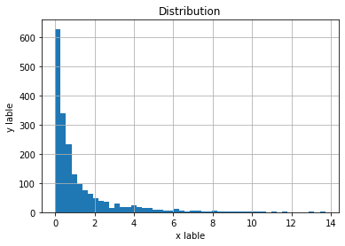

```python
murders['PctRecentImmig'].hist(bins=50)
plt.title('Distribution')
plt.xlabel('x lable')
plt.ylabel('y lable')
plt.show()
```

```python
#Check the minimum and maximum value
print(murders['PctRecentImmig'].min())
print(murders['PctRecentImmig'].max())

#Determine bins based on quantiles
PctRecentImmig_ = pd.qcut(murders['PctRecentImmig'], q=4)
#Check the value counts of each bin to ensure they are balanced
PctRecentImmig_.value_counts()

#Create bin labels
PctRecentImmig_labels = ['0-0.2%', '0.2-0.5%', '0.5-1.3%', '1.3-13.7%']
#Create bins
PctRecentImmig_bin = [-1, 0.2, 0.5, 1.3, 13.71]
#Add new category
murders['PctRecentImmig_bins'] = pd.cut(murders['PctRecentImmig'], bins=PctRecentImmig_bin, labels=PctRecentImmig_labels)
murders.head()
```

```
0.0
13.71
```

|  | communityname | state | population | householdsize | racepctblack | racePctWhite | racePctAsian | racePctHisp | agePct12t21 | agePct65up | pctUrban | medIncome | pctWFarmSelf | pctWInvInc | pctWPubAsst | pctWRetire | blackPerCap | indianPerCap | AsianPerCap | OtherPerCap | HispPerCap | PctPopUnderPov | PctLess9thGrade | PctBSorMore | PctEmplManu | PctEmplProfServ | PctOccupManu | MalePctDivorce | MalePctNevMarr | … |
| --- | --- | --- | --- | --- | --- | --- | --- | --- | --- | --- | --- | --- | --- | --- | --- | --- | --- | --- | --- | --- | --- | --- | --- | --- | --- | --- | --- | --- | --- | --- |
| 0 | BerkeleyHeightstownship | NJ | 11980 | 3.10 | 1.37 | 91.78 | 6.50 | 1.88 | 12.47 | 11.33 | 100.0 | 75122 | 1.55 | 70.20 | 1.03 | 18.39 | 13600 | 5725 | 27101 | 5115.0 | 22838 | 1.96 | 5.81 | 48.18 | 14.65 | 28.82 | 5.49 | 3.67 | 26.38 | … |
| 1 | Marpletownship | PA | 23123 | 2.82 | 0.80 | 95.57 | 3.44 | 0.85 | 11.01 | 17.18 | 100.0 | 47917 | 1.11 | 64.11 | 2.75 | 22.85 | 18137 | 0 | 20074 | 5250.0 | 12222 | 3.98 | 5.61 | 29.89 | 12.26 | 29.28 | 6.39 | 4.23 | 27.99 | … |
| 2 | Tigardcity | OR | 29344 | 2.43 | 0.74 | 94.33 | 3.43 | 2.35 | 11.36 | 10.28 | 100.0 | 35669 | 1.15 | 55.73 | 2.94 | 14.56 | 16644 | 21606 | 15528 | 5954.0 | 8405 | 4.75 | 2.80 | 30.13 | 15.95 | 21.52 | 8.79 | 10.10 | 25.78 | … |
| 4 | Springfieldcity | MO | 140494 | 2.45 | 2.51 | 95.65 | 0.90 | 0.95 | 18.09 | 13.26 | 100.0 | 21577 | 1.00 | 41.15 | 7.12 | 14.09 | 7382 | 10264 | 10753 | 7192.0 | 8104 | 17.78 | 8.76 | 20.66 | 14.31 | 26.83 | 14.72 | 11.40 | 33.32 | … |
| 5 | Norwoodtown | MA | 28700 | 2.60 | 1.60 | 96.57 | 1.47 | 1.10 | 11.17 | 14.42 | 100.0 | 42805 | 0.39 | 47.70 | 5.41 | 17.23 | 17342 | 21482 | 12639 | 21852.0 | 22594 | 4.01 | 4.49 | 27.01 | 14.02 | 27.17 | 8.50 | 5.97 | 36.05 | … |

```python
murders['PctRecentImmig_bins'].value_counts()
```

```
0-0.2%       526
1.3-13.7%    516
0.5-1.3%     474
0.2-0.5%     403
Name: PctRecentImmig_bins, dtype: int64
```

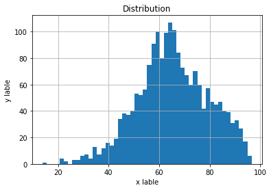

```python
murders['PctPersOwnOccup'].hist(bins=50)
plt.title('Distribution')
plt.xlabel('x lable')
plt.ylabel('y lable')
plt.show()
```

```python
# apply normalization technique, using a range of [0,1]
murders['PctPersOwnOccup_norm'] = (murders['PctPersOwnOccup'] - murders['PctPersOwnOccup'].min()) / (murders['PctPersOwnOccup'].max() - murders['PctPersOwnOccup'].min())

murders.head()
```

|  | communityname | state | population | householdsize | racepctblack | racePctWhite | racePctAsian | racePctHisp | agePct12t21 | agePct65up | pctUrban | medIncome | pctWFarmSelf | pctWInvInc | pctWPubAsst | pctWRetire | blackPerCap | indianPerCap | AsianPerCap | OtherPerCap | HispPerCap | PctPopUnderPov | PctLess9thGrade | PctBSorMore | PctEmplManu | PctEmplProfServ | PctOccupManu | MalePctDivorce | MalePctNevMarr | … |
| --- | --- | --- | --- | --- | --- | --- | --- | --- | --- | --- | --- | --- | --- | --- | --- | --- | --- | --- | --- | --- | --- | --- | --- | --- | --- | --- | --- | --- | --- | --- |
| 0 | BerkeleyHeightstownship | NJ | 11980 | 3.10 | 1.37 | 91.78 | 6.50 | 1.88 | 12.47 | 11.33 | 100.0 | 75122 | 1.55 | 70.20 | 1.03 | 18.39 | 13600 | 5725 | 27101 | 5115.0 | 22838 | 1.96 | 5.81 | 48.18 | 14.65 | 28.82 | 5.49 | 3.67 | 26.38 | … |
| 1 | Marpletownship | PA | 23123 | 2.82 | 0.80 | 95.57 | 3.44 | 0.85 | 11.01 | 17.18 | 100.0 | 47917 | 1.11 | 64.11 | 2.75 | 22.85 | 18137 | 0 | 20074 | 5250.0 | 12222 | 3.98 | 5.61 | 29.89 | 12.26 | 29.28 | 6.39 | 4.23 | 27.99 | … |
| 2 | Tigardcity | OR | 29344 | 2.43 | 0.74 | 94.33 | 3.43 | 2.35 | 11.36 | 10.28 | 100.0 | 35669 | 1.15 | 55.73 | 2.94 | 14.56 | 16644 | 21606 | 15528 | 5954.0 | 8405 | 4.75 | 2.80 | 30.13 | 15.95 | 21.52 | 8.79 | 10.10 | 25.78 | … |
| 4 | Springfieldcity | MO | 140494 | 2.45 | 2.51 | 95.65 | 0.90 | 0.95 | 18.09 | 13.26 | 100.0 | 21577 | 1.00 | 41.15 | 7.12 | 14.09 | 7382 | 10264 | 10753 | 7192.0 | 8104 | 17.78 | 8.76 | 20.66 | 14.31 | 26.83 | 14.72 | 11.40 | 33.32 | … |
| 5 | Norwoodtown | MA | 28700 | 2.60 | 1.60 | 96.57 | 1.47 | 1.10 | 11.17 | 14.42 | 100.0 | 42805 | 0.39 | 47.70 | 5.41 | 17.23 | 17342 | 21482 | 12639 | 21852.0 | 22594 | 4.01 | 4.49 | 27.01 | 14.02 | 27.17 | 8.50 | 5.97 | 36.05 | … |

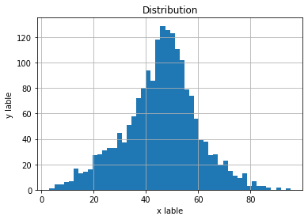

```python
murders['PctHousLess3BR'].hist(bins=50)
plt.title('Distribution')
plt.xlabel('x lable')
plt.ylabel('y lable')
plt.show()
```

```python
# apply normalization technique, using a range of [0,1]
murders['PctHousLess3BR_norm'] = (murders['PctHousLess3BR'] - murders['PctHousLess3BR'].min()) / (murders['PctHousLess3BR'].max() - murders['PctHousLess3BR'].min())

murders.head()
```

|  | communityname | state | population | householdsize | racepctblack | racePctWhite | racePctAsian | racePctHisp | agePct12t21 | agePct65up | pctUrban | medIncome | pctWFarmSelf | pctWInvInc | pctWPubAsst | pctWRetire | blackPerCap | indianPerCap | AsianPerCap | OtherPerCap | HispPerCap | PctPopUnderPov | PctLess9thGrade | PctBSorMore | PctEmplManu | PctEmplProfServ | PctOccupManu | MalePctDivorce | MalePctNevMarr | … |
| --- | --- | --- | --- | --- | --- | --- | --- | --- | --- | --- | --- | --- | --- | --- | --- | --- | --- | --- | --- | --- | --- | --- | --- | --- | --- | --- | --- | --- | --- | --- |
| 0 | BerkeleyHeightstownship | NJ | 11980 | 3.10 | 1.37 | 91.78 | 6.50 | 1.88 | 12.47 | 11.33 | 100.0 | 75122 | 1.55 | 70.20 | 1.03 | 18.39 | 13600 | 5725 | 27101 | 5115.0 | 22838 | 1.96 | 5.81 | 48.18 | 14.65 | 28.82 | 5.49 | 3.67 | 26.38 | … |
| 1 | Marpletownship | PA | 23123 | 2.82 | 0.80 | 95.57 | 3.44 | 0.85 | 11.01 | 17.18 | 100.0 | 47917 | 1.11 | 64.11 | 2.75 | 22.85 | 18137 | 0 | 20074 | 5250.0 | 12222 | 3.98 | 5.61 | 29.89 | 12.26 | 29.28 | 6.39 | 4.23 | 27.99 | … |
| 2 | Tigardcity | OR | 29344 | 2.43 | 0.74 | 94.33 | 3.43 | 2.35 | 11.36 | 10.28 | 100.0 | 35669 | 1.15 | 55.73 | 2.94 | 14.56 | 16644 | 21606 | 15528 | 5954.0 | 8405 | 4.75 | 2.80 | 30.13 | 15.95 | 21.52 | 8.79 | 10.10 | 25.78 | … |
| 4 | Springfieldcity | MO | 140494 | 2.45 | 2.51 | 95.65 | 0.90 | 0.95 | 18.09 | 13.26 | 100.0 | 21577 | 1.00 | 41.15 | 7.12 | 14.09 | 7382 | 10264 | 10753 | 7192.0 | 8104 | 17.78 | 8.76 | 20.66 | 14.31 | 26.83 | 14.72 | 11.40 | 33.32 | … |
| 5 | Norwoodtown | MA | 28700 | 2.60 | 1.60 | 96.57 | 1.47 | 1.10 | 11.17 | 14.42 | 100.0 | 42805 | 0.39 | 47.70 | 5.41 | 17.23 | 17342 | 21482 | 12639 | 21852.0 | 22594 | 4.01 | 4.49 | 27.01 | 14.02 | 27.17 | 8.50 | 5.97 | 36.05 | … |

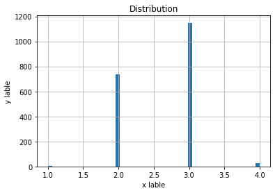

```python
murders['MedNumBR'].hist(bins=50)
plt.title('Distribution')
plt.xlabel('x lable')
plt.ylabel('y lable')
plt.show()
```

```python
#Check the minimum and maximum value
print(murders['MedNumBR'].min())
print(murders['MedNumBR'].max())

#Determine bins based on quantiles
murders['MedNumBR'].describe()

#Create bin labels
MedNumBR_labels = ['0-2.5', '2.5-4']
#Create bins
MedNumBR_bin = [0, 2.5, 4]
#Add new category
murders['MedNumBR_bins'] = pd.cut(murders['MedNumBR'], bins=MedNumBR_bin, labels=MedNumBR_labels)
murders.head()
```

```
1
4
```

|  | communityname | state | population | householdsize | racepctblack | racePctWhite | racePctAsian | racePctHisp | agePct12t21 | agePct65up | pctUrban | medIncome | pctWFarmSelf | pctWInvInc | pctWPubAsst | pctWRetire | blackPerCap | indianPerCap | AsianPerCap | OtherPerCap | HispPerCap | PctPopUnderPov | PctLess9thGrade | PctBSorMore | PctEmplManu | PctEmplProfServ | PctOccupManu | MalePctDivorce | MalePctNevMarr | … |
| --- | --- | --- | --- | --- | --- | --- | --- | --- | --- | --- | --- | --- | --- | --- | --- | --- | --- | --- | --- | --- | --- | --- | --- | --- | --- | --- | --- | --- | --- | --- |
| 0 | BerkeleyHeightstownship | NJ | 11980 | 3.10 | 1.37 | 91.78 | 6.50 | 1.88 | 12.47 | 11.33 | 100.0 | 75122 | 1.55 | 70.20 | 1.03 | 18.39 | 13600 | 5725 | 27101 | 5115.0 | 22838 | 1.96 | 5.81 | 48.18 | 14.65 | 28.82 | 5.49 | 3.67 | 26.38 | … |
| 1 | Marpletownship | PA | 23123 | 2.82 | 0.80 | 95.57 | 3.44 | 0.85 | 11.01 | 17.18 | 100.0 | 47917 | 1.11 | 64.11 | 2.75 | 22.85 | 18137 | 0 | 20074 | 5250.0 | 12222 | 3.98 | 5.61 | 29.89 | 12.26 | 29.28 | 6.39 | 4.23 | 27.99 | … |
| 2 | Tigardcity | OR | 29344 | 2.43 | 0.74 | 94.33 | 3.43 | 2.35 | 11.36 | 10.28 | 100.0 | 35669 | 1.15 | 55.73 | 2.94 | 14.56 | 16644 | 21606 | 15528 | 5954.0 | 8405 | 4.75 | 2.80 | 30.13 | 15.95 | 21.52 | 8.79 | 10.10 | 25.78 | … |
| 4 | Springfieldcity | MO | 140494 | 2.45 | 2.51 | 95.65 | 0.90 | 0.95 | 18.09 | 13.26 | 100.0 | 21577 | 1.00 | 41.15 | 7.12 | 14.09 | 7382 | 10264 | 10753 | 7192.0 | 8104 | 17.78 | 8.76 | 20.66 | 14.31 | 26.83 | 14.72 | 11.40 | 33.32 | … |
| 5 | Norwoodtown | MA | 28700 | 2.60 | 1.60 | 96.57 | 1.47 | 1.10 | 11.17 | 14.42 | 100.0 | 42805 | 0.39 | 47.70 | 5.41 | 17.23 | 17342 | 21482 | 12639 | 21852.0 | 22594 | 4.01 | 4.49 | 27.01 | 14.02 | 27.17 | 8.50 | 5.97 | 36.05 | … |

```python
murders['MedNumBR_bins'].value_counts()
```

```
2.5-4    1176
0-2.5     743
Name: MedNumBR_bins, dtype: int64
```

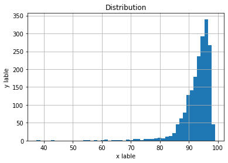

```python
murders['PctHousOccup'].hist(bins=50)
plt.title('Distribution')
plt.xlabel('x lable')
plt.ylabel('y lable')
plt.show()
```

```python
#Check the minimum and maximum value
print(murders['PctHousOccup'].min())
print(murders['PctHousOccup'].max())

#Determine bins based on quantiles
PctHousOccup_ = pd.qcut(murders['PctHousOccup'], q=4)
#Check the value counts of each bin to ensure they are balanced
PctHousOccup_.value_counts()

#Create bin labels
PctHousOccup_labels = ['30-91%', '91-94%', '94-96%', '96-99%']
#Create bins
PctHousOccup_bin = [30, 91, 94, 96, 99]
#Add new category
murders['PctHousOccup_bins'] = pd.cut(murders['PctHousOccup'], bins=PctHousOccup_bin, labels=PctHousOccup_labels)
murders.head()
```

```
37.47
99.0
```

|  | communityname | state | population | householdsize | racepctblack | racePctWhite | racePctAsian | racePctHisp | agePct12t21 | agePct65up | pctUrban | medIncome | pctWFarmSelf | pctWInvInc | pctWPubAsst | pctWRetire | blackPerCap | indianPerCap | AsianPerCap | OtherPerCap | HispPerCap | PctPopUnderPov | PctLess9thGrade | PctBSorMore | PctEmplManu | PctEmplProfServ | PctOccupManu | MalePctDivorce | MalePctNevMarr | … |
| --- | --- | --- | --- | --- | --- | --- | --- | --- | --- | --- | --- | --- | --- | --- | --- | --- | --- | --- | --- | --- | --- | --- | --- | --- | --- | --- | --- | --- | --- | --- |
| 0 | BerkeleyHeightstownship | NJ | 11980 | 3.10 | 1.37 | 91.78 | 6.50 | 1.88 | 12.47 | 11.33 | 100.0 | 75122 | 1.55 | 70.20 | 1.03 | 18.39 | 13600 | 5725 | 27101 | 5115.0 | 22838 | 1.96 | 5.81 | 48.18 | 14.65 | 28.82 | 5.49 | 3.67 | 26.38 | … |
| 1 | Marpletownship | PA | 23123 | 2.82 | 0.80 | 95.57 | 3.44 | 0.85 | 11.01 | 17.18 | 100.0 | 47917 | 1.11 | 64.11 | 2.75 | 22.85 | 18137 | 0 | 20074 | 5250.0 | 12222 | 3.98 | 5.61 | 29.89 | 12.26 | 29.28 | 6.39 | 4.23 | 27.99 | … |
| 2 | Tigardcity | OR | 29344 | 2.43 | 0.74 | 94.33 | 3.43 | 2.35 | 11.36 | 10.28 | 100.0 | 35669 | 1.15 | 55.73 | 2.94 | 14.56 | 16644 | 21606 | 15528 | 5954.0 | 8405 | 4.75 | 2.80 | 30.13 | 15.95 | 21.52 | 8.79 | 10.10 | 25.78 | … |
| 4 | Springfieldcity | MO | 140494 | 2.45 | 2.51 | 95.65 | 0.90 | 0.95 | 18.09 | 13.26 | 100.0 | 21577 | 1.00 | 41.15 | 7.12 | 14.09 | 7382 | 10264 | 10753 | 7192.0 | 8104 | 17.78 | 8.76 | 20.66 | 14.31 | 26.83 | 14.72 | 11.40 | 33.32 | … |
| 5 | Norwoodtown | MA | 28700 | 2.60 | 1.60 | 96.57 | 1.47 | 1.10 | 11.17 | 14.42 | 100.0 | 42805 | 0.39 | 47.70 | 5.41 | 17.23 | 17342 | 21482 | 12639 | 21852.0 | 22594 | 4.01 | 4.49 | 27.01 | 14.02 | 27.17 | 8.50 | 5.97 | 36.05 | … |

```python
murders['PctHousOccup_bins'].value_counts()
```

```
94-96%    495
30-91%    486
91-94%    475
96-99%    463
Name: PctHousOccup_bins, dtype: int64
```

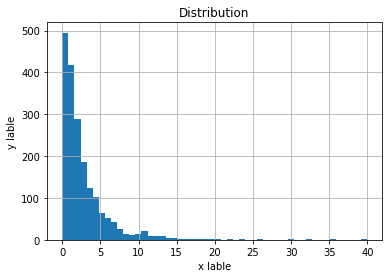

```python
murders['PctVacantBoarded'].hist(bins=50)
plt.title('Distribution')
plt.xlabel('x lable')
plt.ylabel('y lable')
plt.show()
```

```python
#Check the minimum and maximum value
print(murders['PctVacantBoarded'].min())
print(murders['PctVacantBoarded'].max())

#Determine bins based on quantiles
PctVacantBoarded_ = pd.qcut(murders['PctVacantBoarded'], q=4)
#Check the value counts of each bin to ensure they are balanced
PctVacantBoarded_.value_counts()

#Create bin labels
PctVacantBoarded_labels = ['0-0.75%', '0.75-1.75%', '1.75-4%', '4-40%']
#Create bins
PctVacantBoarded_bin = [-1, 0.75, 1.75, 4, 40]
#Add new category
murders['PctVacantBoarded_bins'] = pd.cut(murders['PctVacantBoarded'], bins=PctVacantBoarded_bin, labels=PctVacantBoarded_labels)
murders.head()
```

```
0.0
39.89
```

|  | communityname | state | population | householdsize | racepctblack | racePctWhite | racePctAsian | racePctHisp | agePct12t21 | agePct65up | pctUrban | medIncome | pctWFarmSelf | pctWInvInc | pctWPubAsst | pctWRetire | blackPerCap | indianPerCap | AsianPerCap | OtherPerCap | HispPerCap | PctPopUnderPov | PctLess9thGrade | PctBSorMore | PctEmplManu | PctEmplProfServ | PctOccupManu | MalePctDivorce | MalePctNevMarr | … |
| --- | --- | --- | --- | --- | --- | --- | --- | --- | --- | --- | --- | --- | --- | --- | --- | --- | --- | --- | --- | --- | --- | --- | --- | --- | --- | --- | --- | --- | --- | --- |
| 0 | BerkeleyHeightstownship | NJ | 11980 | 3.10 | 1.37 | 91.78 | 6.50 | 1.88 | 12.47 | 11.33 | 100.0 | 75122 | 1.55 | 70.20 | 1.03 | 18.39 | 13600 | 5725 | 27101 | 5115.0 | 22838 | 1.96 | 5.81 | 48.18 | 14.65 | 28.82 | 5.49 | 3.67 | 26.38 | … |
| 1 | Marpletownship | PA | 23123 | 2.82 | 0.80 | 95.57 | 3.44 | 0.85 | 11.01 | 17.18 | 100.0 | 47917 | 1.11 | 64.11 | 2.75 | 22.85 | 18137 | 0 | 20074 | 5250.0 | 12222 | 3.98 | 5.61 | 29.89 | 12.26 | 29.28 | 6.39 | 4.23 | 27.99 | … |
| 2 | Tigardcity | OR | 29344 | 2.43 | 0.74 | 94.33 | 3.43 | 2.35 | 11.36 | 10.28 | 100.0 | 35669 | 1.15 | 55.73 | 2.94 | 14.56 | 16644 | 21606 | 15528 | 5954.0 | 8405 | 4.75 | 2.80 | 30.13 | 15.95 | 21.52 | 8.79 | 10.10 | 25.78 | … |
| 4 | Springfieldcity | MO | 140494 | 2.45 | 2.51 | 95.65 | 0.90 | 0.95 | 18.09 | 13.26 | 100.0 | 21577 | 1.00 | 41.15 | 7.12 | 14.09 | 7382 | 10264 | 10753 | 7192.0 | 8104 | 17.78 | 8.76 | 20.66 | 14.31 | 26.83 | 14.72 | 11.40 | 33.32 | … |
| 5 | Norwoodtown | MA | 28700 | 2.60 | 1.60 | 96.57 | 1.47 | 1.10 | 11.17 | 14.42 | 100.0 | 42805 | 0.39 | 47.70 | 5.41 | 17.23 | 17342 | 21482 | 12639 | 21852.0 | 22594 | 4.01 | 4.49 | 27.01 | 14.02 | 27.17 | 8.50 | 5.97 | 36.05 | … |

```python
murders['PctVacantBoarded_bins'].value_counts()
```

```
1.75-4%       540
0.75-1.75%    500
0-0.75%       473
4-40%         406
Name: PctVacantBoarded_bins, dtype: int64
```

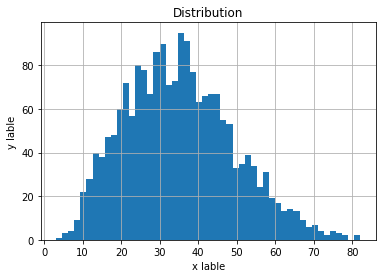

```python
murders['PctVacMore6Mos'].hist(bins=50)
plt.title('Distribution')
plt.xlabel('x lable')
plt.ylabel('y lable')
plt.show()
```

```python
# apply normalization technique, using a range of [0,1]
murders['PctVacMore6Mos_norm'] = (murders['PctVacMore6Mos'] - murders['PctVacMore6Mos'].min()) / (murders['PctVacMore6Mos'].max() - murders['PctVacMore6Mos'].min())

murders.head()
```

|  | communityname | state | population | householdsize | racepctblack | racePctWhite | racePctAsian | racePctHisp | agePct12t21 | agePct65up | pctUrban | medIncome | pctWFarmSelf | pctWInvInc | pctWPubAsst | pctWRetire | blackPerCap | indianPerCap | AsianPerCap | OtherPerCap | HispPerCap | PctPopUnderPov | PctLess9thGrade | PctBSorMore | PctEmplManu | PctEmplProfServ | PctOccupManu | MalePctDivorce | MalePctNevMarr | … |
| --- | --- | --- | --- | --- | --- | --- | --- | --- | --- | --- | --- | --- | --- | --- | --- | --- | --- | --- | --- | --- | --- | --- | --- | --- | --- | --- | --- | --- | --- | --- |
| 0 | BerkeleyHeightstownship | NJ | 11980 | 3.10 | 1.37 | 91.78 | 6.50 | 1.88 | 12.47 | 11.33 | 100.0 | 75122 | 1.55 | 70.20 | 1.03 | 18.39 | 13600 | 5725 | 27101 | 5115.0 | 22838 | 1.96 | 5.81 | 48.18 | 14.65 | 28.82 | 5.49 | 3.67 | 26.38 | … |
| 1 | Marpletownship | PA | 23123 | 2.82 | 0.80 | 95.57 | 3.44 | 0.85 | 11.01 | 17.18 | 100.0 | 47917 | 1.11 | 64.11 | 2.75 | 22.85 | 18137 | 0 | 20074 | 5250.0 | 12222 | 3.98 | 5.61 | 29.89 | 12.26 | 29.28 | 6.39 | 4.23 | 27.99 | … |
| 2 | Tigardcity | OR | 29344 | 2.43 | 0.74 | 94.33 | 3.43 | 2.35 | 11.36 | 10.28 | 100.0 | 35669 | 1.15 | 55.73 | 2.94 | 14.56 | 16644 | 21606 | 15528 | 5954.0 | 8405 | 4.75 | 2.80 | 30.13 | 15.95 | 21.52 | 8.79 | 10.10 | 25.78 | … |
| 4 | Springfieldcity | MO | 140494 | 2.45 | 2.51 | 95.65 | 0.90 | 0.95 | 18.09 | 13.26 | 100.0 | 21577 | 1.00 | 41.15 | 7.12 | 14.09 | 7382 | 10264 | 10753 | 7192.0 | 8104 | 17.78 | 8.76 | 20.66 | 14.31 | 26.83 | 14.72 | 11.40 | 33.32 | … |
| 5 | Norwoodtown | MA | 28700 | 2.60 | 1.60 | 96.57 | 1.47 | 1.10 | 11.17 | 14.42 | 100.0 | 42805 | 0.39 | 47.70 | 5.41 | 17.23 | 17342 | 21482 | 12639 | 21852.0 | 22594 | 4.01 | 4.49 | 27.01 | 14.02 | 27.17 | 8.50 | 5.97 | 36.05 | … |

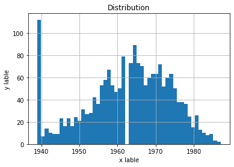

```python
murders['MedYrHousBuilt'].hist(bins=50)
plt.title('Distribution')
plt.xlabel('x lable')
plt.ylabel('y lable')
plt.show()
```

```python
#Check the minimum and maximum value
print(murders['MedYrHousBuilt'].min())
print(murders['MedYrHousBuilt'].max())

#Determine bins based on quantiles
MedYrHousBuilt_ = pd.qcut(murders['MedYrHousBuilt'], q=4)
#Check the value counts of each bin to ensure they are balanced
MedYrHousBuilt_.value_counts()

#Create bin labels
MedYrHousBuilt_labels = ['1939-1956', '1956-1964', '1964-1971', '1971-1987']
#Create bins
MedYrHousBuilt_bin = [0, 1956, 1964, 1971, 1987]
#Add new category
murders['MedYrHousBuilt_bins'] = pd.cut(murders['MedYrHousBuilt'], bins=MedYrHousBuilt_bin, labels=MedYrHousBuilt_labels)
murders.head()
```

```
1939
1987
```

|  | communityname | state | population | householdsize | racepctblack | racePctWhite | racePctAsian | racePctHisp | agePct12t21 | agePct65up | pctUrban | medIncome | pctWFarmSelf | pctWInvInc | pctWPubAsst | pctWRetire | blackPerCap | indianPerCap | AsianPerCap | OtherPerCap | HispPerCap | PctPopUnderPov | PctLess9thGrade | PctBSorMore | PctEmplManu | PctEmplProfServ | PctOccupManu | MalePctDivorce | MalePctNevMarr | … |
| --- | --- | --- | --- | --- | --- | --- | --- | --- | --- | --- | --- | --- | --- | --- | --- | --- | --- | --- | --- | --- | --- | --- | --- | --- | --- | --- | --- | --- | --- | --- |
| 0 | BerkeleyHeightstownship | NJ | 11980 | 3.10 | 1.37 | 91.78 | 6.50 | 1.88 | 12.47 | 11.33 | 100.0 | 75122 | 1.55 | 70.20 | 1.03 | 18.39 | 13600 | 5725 | 27101 | 5115.0 | 22838 | 1.96 | 5.81 | 48.18 | 14.65 | 28.82 | 5.49 | 3.67 | 26.38 | … |
| 1 | Marpletownship | PA | 23123 | 2.82 | 0.80 | 95.57 | 3.44 | 0.85 | 11.01 | 17.18 | 100.0 | 47917 | 1.11 | 64.11 | 2.75 | 22.85 | 18137 | 0 | 20074 | 5250.0 | 12222 | 3.98 | 5.61 | 29.89 | 12.26 | 29.28 | 6.39 | 4.23 | 27.99 | … |
| 2 | Tigardcity | OR | 29344 | 2.43 | 0.74 | 94.33 | 3.43 | 2.35 | 11.36 | 10.28 | 100.0 | 35669 | 1.15 | 55.73 | 2.94 | 14.56 | 16644 | 21606 | 15528 | 5954.0 | 8405 | 4.75 | 2.80 | 30.13 | 15.95 | 21.52 | 8.79 | 10.10 | 25.78 | … |
| 4 | Springfieldcity | MO | 140494 | 2.45 | 2.51 | 95.65 | 0.90 | 0.95 | 18.09 | 13.26 | 100.0 | 21577 | 1.00 | 41.15 | 7.12 | 14.09 | 7382 | 10264 | 10753 | 7192.0 | 8104 | 17.78 | 8.76 | 20.66 | 14.31 | 26.83 | 14.72 | 11.40 | 33.32 | … |
| 5 | Norwoodtown | MA | 28700 | 2.60 | 1.60 | 96.57 | 1.47 | 1.10 | 11.17 | 14.42 | 100.0 | 42805 | 0.39 | 47.70 | 5.41 | 17.23 | 17342 | 21482 | 12639 | 21852.0 | 22594 | 4.01 | 4.49 | 27.01 | 14.02 | 27.17 | 8.50 | 5.97 | 36.05 | … |

```python
murders['MedYrHousBuilt_bins'].value_counts()
```

```
1956-1964    516
1939-1956    501
1964-1971    454
1971-1987    448
Name: MedYrHousBuilt_bins, dtype: int64
```

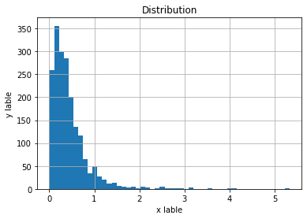

```python
murders['PctWOFullPlumb'].hist(bins=50)
plt.title('Distribution')
plt.xlabel('x lable')
plt.ylabel('y lable')
plt.show()
```

```python
#Check the minimum and maximum value
print(murders['PctWOFullPlumb'].min())
print(murders['PctWOFullPlumb'].max())

#Determine bins based on quantiles
PctWOFullPlumb_ = pd.qcut(murders['PctWOFullPlumb'], q=4)
#Check the value counts of each bin to ensure they are balanced
PctWOFullPlumb_.value_counts()

#Create bin labels
PctWOFullPlumb_labels = ['0-0.16%', '0.16-0.3%', '0.3-0.5%', '0.5-5%']
#Create bins
PctWOFullPlumb_bin = [-1, 0.16, 0.3, 0.5, 5.33]
#Add new category
murders['PctWOFullPlumb_bins'] = pd.cut(murders['PctWOFullPlumb'], bins=PctWOFullPlumb_bin, labels=PctWOFullPlumb_labels)
murders.head()
```

```
0.0
5.33
```

|  | communityname | state | population | householdsize | racepctblack | racePctWhite | racePctAsian | racePctHisp | agePct12t21 | agePct65up | pctUrban | medIncome | pctWFarmSelf | pctWInvInc | pctWPubAsst | pctWRetire | blackPerCap | indianPerCap | AsianPerCap | OtherPerCap | HispPerCap | PctPopUnderPov | PctLess9thGrade | PctBSorMore | PctEmplManu | PctEmplProfServ | PctOccupManu | MalePctDivorce | MalePctNevMarr | … |
| --- | --- | --- | --- | --- | --- | --- | --- | --- | --- | --- | --- | --- | --- | --- | --- | --- | --- | --- | --- | --- | --- | --- | --- | --- | --- | --- | --- | --- | --- | --- |
| 0 | BerkeleyHeightstownship | NJ | 11980 | 3.10 | 1.37 | 91.78 | 6.50 | 1.88 | 12.47 | 11.33 | 100.0 | 75122 | 1.55 | 70.20 | 1.03 | 18.39 | 13600 | 5725 | 27101 | 5115.0 | 22838 | 1.96 | 5.81 | 48.18 | 14.65 | 28.82 | 5.49 | 3.67 | 26.38 | … |
| 1 | Marpletownship | PA | 23123 | 2.82 | 0.80 | 95.57 | 3.44 | 0.85 | 11.01 | 17.18 | 100.0 | 47917 | 1.11 | 64.11 | 2.75 | 22.85 | 18137 | 0 | 20074 | 5250.0 | 12222 | 3.98 | 5.61 | 29.89 | 12.26 | 29.28 | 6.39 | 4.23 | 27.99 | … |
| 2 | Tigardcity | OR | 29344 | 2.43 | 0.74 | 94.33 | 3.43 | 2.35 | 11.36 | 10.28 | 100.0 | 35669 | 1.15 | 55.73 | 2.94 | 14.56 | 16644 | 21606 | 15528 | 5954.0 | 8405 | 4.75 | 2.80 | 30.13 | 15.95 | 21.52 | 8.79 | 10.10 | 25.78 | … |
| 4 | Springfieldcity | MO | 140494 | 2.45 | 2.51 | 95.65 | 0.90 | 0.95 | 18.09 | 13.26 | 100.0 | 21577 | 1.00 | 41.15 | 7.12 | 14.09 | 7382 | 10264 | 10753 | 7192.0 | 8104 | 17.78 | 8.76 | 20.66 | 14.31 | 26.83 | 14.72 | 11.40 | 33.32 | … |
| 5 | Norwoodtown | MA | 28700 | 2.60 | 1.60 | 96.57 | 1.47 | 1.10 | 11.17 | 14.42 | 100.0 | 42805 | 0.39 | 47.70 | 5.41 | 17.23 | 17342 | 21482 | 12639 | 21852.0 | 22594 | 4.01 | 4.49 | 27.01 | 14.02 | 27.17 | 8.50 | 5.97 | 36.05 | … |

```python
murders['PctWOFullPlumb_bins'].value_counts()
```

```
0.5-5%       564
0.3-0.5%     475
0-0.16%      453
0.16-0.3%    427
Name: PctWOFullPlumb_bins, dtype: int64
```

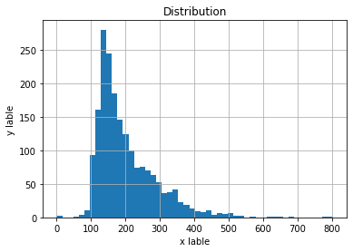

```python
murders['RentQrange'].hist(bins=50)
plt.title('Distribution')
plt.xlabel('x lable')
plt.ylabel('y lable')
plt.show()
```

```python
#Check the minimum and maximum value
print(murders['RentQrange'].min())
print(murders['RentQrange'].max())

#Determine bins based on quantiles
RentQrange_ = pd.qcut(murders['RentQrange'], q=4)
#Check the value counts of each bin to ensure they are balanced
RentQrange_.value_counts()


#Create bin labels
RentQrange_labels = ['0-140', '140-170', '170-230', '230-805']
#Create bins
RentQrange_bin = [-1, 140, 170, 230, 803]
#Add new category
murders['RentQrange_bins'] = pd.cut(murders['RentQrange'], bins=RentQrange_bin, labels=RentQrange_labels)
murders.head()
```

```
0
803
```

|  | communityname | state | population | householdsize | racepctblack | racePctWhite | racePctAsian | racePctHisp | agePct12t21 | agePct65up | pctUrban | medIncome | pctWFarmSelf | pctWInvInc | pctWPubAsst | pctWRetire | blackPerCap | indianPerCap | AsianPerCap | OtherPerCap | HispPerCap | PctPopUnderPov | PctLess9thGrade | PctBSorMore | PctEmplManu | PctEmplProfServ | PctOccupManu | MalePctDivorce | MalePctNevMarr | … |
| --- | --- | --- | --- | --- | --- | --- | --- | --- | --- | --- | --- | --- | --- | --- | --- | --- | --- | --- | --- | --- | --- | --- | --- | --- | --- | --- | --- | --- | --- | --- |
| 0 | BerkeleyHeightstownship | NJ | 11980 | 3.10 | 1.37 | 91.78 | 6.50 | 1.88 | 12.47 | 11.33 | 100.0 | 75122 | 1.55 | 70.20 | 1.03 | 18.39 | 13600 | 5725 | 27101 | 5115.0 | 22838 | 1.96 | 5.81 | 48.18 | 14.65 | 28.82 | 5.49 | 3.67 | 26.38 | … |
| 1 | Marpletownship | PA | 23123 | 2.82 | 0.80 | 95.57 | 3.44 | 0.85 | 11.01 | 17.18 | 100.0 | 47917 | 1.11 | 64.11 | 2.75 | 22.85 | 18137 | 0 | 20074 | 5250.0 | 12222 | 3.98 | 5.61 | 29.89 | 12.26 | 29.28 | 6.39 | 4.23 | 27.99 | … |
| 2 | Tigardcity | OR | 29344 | 2.43 | 0.74 | 94.33 | 3.43 | 2.35 | 11.36 | 10.28 | 100.0 | 35669 | 1.15 | 55.73 | 2.94 | 14.56 | 16644 | 21606 | 15528 | 5954.0 | 8405 | 4.75 | 2.80 | 30.13 | 15.95 | 21.52 | 8.79 | 10.10 | 25.78 | … |
| 4 | Springfieldcity | MO | 140494 | 2.45 | 2.51 | 95.65 | 0.90 | 0.95 | 18.09 | 13.26 | 100.0 | 21577 | 1.00 | 41.15 | 7.12 | 14.09 | 7382 | 10264 | 10753 | 7192.0 | 8104 | 17.78 | 8.76 | 20.66 | 14.31 | 26.83 | 14.72 | 11.40 | 33.32 | … |
| 5 | Norwoodtown | MA | 28700 | 2.60 | 1.60 | 96.57 | 1.47 | 1.10 | 11.17 | 14.42 | 100.0 | 42805 | 0.39 | 47.70 | 5.41 | 17.23 | 17342 | 21482 | 12639 | 21852.0 | 22594 | 4.01 | 4.49 | 27.01 | 14.02 | 27.17 | 8.50 | 5.97 | 36.05 | … |

```python
murders['RentQrange_bins'].value_counts()
```

```
230-805    534
0-140      489
170-230    482
140-170    414
Name: RentQrange_bins, dtype: int64
```

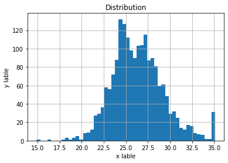

```python
murders['MedRentPctHousInc'].hist(bins=50)
plt.title('Distribution')
plt.xlabel('x lable')
plt.ylabel('y lable')
plt.show()
```

```python
# apply normalization technique, using a range of [0,1]
murders['MedRentPctHousInc_norm'] = (murders['MedRentPctHousInc'] - murders['MedRentPctHousInc'].min()) / (murders['MedRentPctHousInc'].max() - murders['MedRentPctHousInc'].min())

murders.head()
```

|  | communityname | state | population | householdsize | racepctblack | racePctWhite | racePctAsian | racePctHisp | agePct12t21 | agePct65up | pctUrban | medIncome | pctWFarmSelf | pctWInvInc | pctWPubAsst | pctWRetire | blackPerCap | indianPerCap | AsianPerCap | OtherPerCap | HispPerCap | PctPopUnderPov | PctLess9thGrade | PctBSorMore | PctEmplManu | PctEmplProfServ | PctOccupManu | MalePctDivorce | MalePctNevMarr | … |
| --- | --- | --- | --- | --- | --- | --- | --- | --- | --- | --- | --- | --- | --- | --- | --- | --- | --- | --- | --- | --- | --- | --- | --- | --- | --- | --- | --- | --- | --- | --- |
| 0 | BerkeleyHeightstownship | NJ | 11980 | 3.10 | 1.37 | 91.78 | 6.50 | 1.88 | 12.47 | 11.33 | 100.0 | 75122 | 1.55 | 70.20 | 1.03 | 18.39 | 13600 | 5725 | 27101 | 5115.0 | 22838 | 1.96 | 5.81 | 48.18 | 14.65 | 28.82 | 5.49 | 3.67 | 26.38 | … |
| 1 | Marpletownship | PA | 23123 | 2.82 | 0.80 | 95.57 | 3.44 | 0.85 | 11.01 | 17.18 | 100.0 | 47917 | 1.11 | 64.11 | 2.75 | 22.85 | 18137 | 0 | 20074 | 5250.0 | 12222 | 3.98 | 5.61 | 29.89 | 12.26 | 29.28 | 6.39 | 4.23 | 27.99 | … |
| 2 | Tigardcity | OR | 29344 | 2.43 | 0.74 | 94.33 | 3.43 | 2.35 | 11.36 | 10.28 | 100.0 | 35669 | 1.15 | 55.73 | 2.94 | 14.56 | 16644 | 21606 | 15528 | 5954.0 | 8405 | 4.75 | 2.80 | 30.13 | 15.95 | 21.52 | 8.79 | 10.10 | 25.78 | … |
| 4 | Springfieldcity | MO | 140494 | 2.45 | 2.51 | 95.65 | 0.90 | 0.95 | 18.09 | 13.26 | 100.0 | 21577 | 1.00 | 41.15 | 7.12 | 14.09 | 7382 | 10264 | 10753 | 7192.0 | 8104 | 17.78 | 8.76 | 20.66 | 14.31 | 26.83 | 14.72 | 11.40 | 33.32 | … |
| 5 | Norwoodtown | MA | 28700 | 2.60 | 1.60 | 96.57 | 1.47 | 1.10 | 11.17 | 14.42 | 100.0 | 42805 | 0.39 | 47.70 | 5.41 | 17.23 | 17342 | 21482 | 12639 | 21852.0 | 22594 | 4.01 | 4.49 | 27.01 | 14.02 | 27.17 | 8.50 | 5.97 | 36.05 | … |

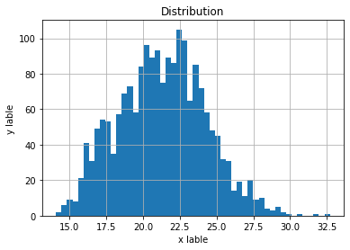

```python
murders['MedOwnCostPctInc'].hist(bins=50)
plt.title('Distribution')
plt.xlabel('x lable')
plt.ylabel('y lable')
plt.show()
```

```python
# apply normalization technique, using a range of [0,1]
murders['MedOwnCostPctInc_norm'] = (murders['MedOwnCostPctInc'] - murders['MedOwnCostPctInc'].min()) / (murders['MedOwnCostPctInc'].max() - murders['MedOwnCostPctInc'].min())

murders.head()
```

|  | communityname | state | population | householdsize | racepctblack | racePctWhite | racePctAsian | racePctHisp | agePct12t21 | agePct65up | pctUrban | medIncome | pctWFarmSelf | pctWInvInc | pctWPubAsst | pctWRetire | blackPerCap | indianPerCap | AsianPerCap | OtherPerCap | HispPerCap | PctPopUnderPov | PctLess9thGrade | PctBSorMore | PctEmplManu | PctEmplProfServ | PctOccupManu | MalePctDivorce | MalePctNevMarr | … |
| --- | --- | --- | --- | --- | --- | --- | --- | --- | --- | --- | --- | --- | --- | --- | --- | --- | --- | --- | --- | --- | --- | --- | --- | --- | --- | --- | --- | --- | --- | --- |
| 0 | BerkeleyHeightstownship | NJ | 11980 | 3.10 | 1.37 | 91.78 | 6.50 | 1.88 | 12.47 | 11.33 | 100.0 | 75122 | 1.55 | 70.20 | 1.03 | 18.39 | 13600 | 5725 | 27101 | 5115.0 | 22838 | 1.96 | 5.81 | 48.18 | 14.65 | 28.82 | 5.49 | 3.67 | 26.38 | … |
| 1 | Marpletownship | PA | 23123 | 2.82 | 0.80 | 95.57 | 3.44 | 0.85 | 11.01 | 17.18 | 100.0 | 47917 | 1.11 | 64.11 | 2.75 | 22.85 | 18137 | 0 | 20074 | 5250.0 | 12222 | 3.98 | 5.61 | 29.89 | 12.26 | 29.28 | 6.39 | 4.23 | 27.99 | … |
| 2 | Tigardcity | OR | 29344 | 2.43 | 0.74 | 94.33 | 3.43 | 2.35 | 11.36 | 10.28 | 100.0 | 35669 | 1.15 | 55.73 | 2.94 | 14.56 | 16644 | 21606 | 15528 | 5954.0 | 8405 | 4.75 | 2.80 | 30.13 | 15.95 | 21.52 | 8.79 | 10.10 | 25.78 | … |
| 4 | Springfieldcity | MO | 140494 | 2.45 | 2.51 | 95.65 | 0.90 | 0.95 | 18.09 | 13.26 | 100.0 | 21577 | 1.00 | 41.15 | 7.12 | 14.09 | 7382 | 10264 | 10753 | 7192.0 | 8104 | 17.78 | 8.76 | 20.66 | 14.31 | 26.83 | 14.72 | 11.40 | 33.32 | … |
| 5 | Norwoodtown | MA | 28700 | 2.60 | 1.60 | 96.57 | 1.47 | 1.10 | 11.17 | 14.42 | 100.0 | 42805 | 0.39 | 47.70 | 5.41 | 17.23 | 17342 | 21482 | 12639 | 21852.0 | 22594 | 4.01 | 4.49 | 27.01 | 14.02 | 27.17 | 8.50 | 5.97 | 36.05 | … |

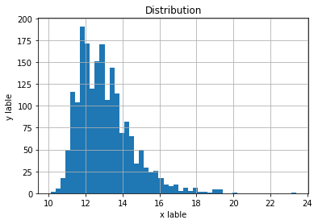

```python
murders['MedOwnCostPctIncNoMtg'].hist(bins=50)
plt.title('Distribution')
plt.xlabel('x lable')
plt.ylabel('y lable')
plt.show()
```

```python
#Check the minimum and maximum value
print(murders['MedOwnCostPctIncNoMtg'].min())
print(murders['MedOwnCostPctIncNoMtg'].max())

#Determine bins based on quantiles
MedOwnCostPctIncNoMtg_ = pd.qcut(murders['MedOwnCostPctIncNoMtg'], q=4)
#Check the value counts of each bin to ensure they are balanced
MedOwnCostPctIncNoMtg_.value_counts()

#Create bin labels
MedOwnCostPctIncNoMtg_labels = ['10-12%', '12-13%', '13-14%', '14-25%']
#Create bins
MedOwnCostPctIncNoMtg_bin = [10, 12, 13, 14, 25]
#Add new category
murders['MedOwnCostPctIncNoMtg_bins'] = pd.cut(murders['MedOwnCostPctIncNoMtg'], bins=MedOwnCostPctIncNoMtg_bin, labels=MedOwnCostPctIncNoMtg_labels)
murders.head()
```

```
10.1
23.4
```

|  | communityname | state | population | householdsize | racepctblack | racePctWhite | racePctAsian | racePctHisp | agePct12t21 | agePct65up | pctUrban | medIncome | pctWFarmSelf | pctWInvInc | pctWPubAsst | pctWRetire | blackPerCap | indianPerCap | AsianPerCap | OtherPerCap | HispPerCap | PctPopUnderPov | PctLess9thGrade | PctBSorMore | PctEmplManu | PctEmplProfServ | PctOccupManu | MalePctDivorce | MalePctNevMarr | … |
| --- | --- | --- | --- | --- | --- | --- | --- | --- | --- | --- | --- | --- | --- | --- | --- | --- | --- | --- | --- | --- | --- | --- | --- | --- | --- | --- | --- | --- | --- | --- |
| 0 | BerkeleyHeightstownship | NJ | 11980 | 3.10 | 1.37 | 91.78 | 6.50 | 1.88 | 12.47 | 11.33 | 100.0 | 75122 | 1.55 | 70.20 | 1.03 | 18.39 | 13600 | 5725 | 27101 | 5115.0 | 22838 | 1.96 | 5.81 | 48.18 | 14.65 | 28.82 | 5.49 | 3.67 | 26.38 | … |
| 1 | Marpletownship | PA | 23123 | 2.82 | 0.80 | 95.57 | 3.44 | 0.85 | 11.01 | 17.18 | 100.0 | 47917 | 1.11 | 64.11 | 2.75 | 22.85 | 18137 | 0 | 20074 | 5250.0 | 12222 | 3.98 | 5.61 | 29.89 | 12.26 | 29.28 | 6.39 | 4.23 | 27.99 | … |
| 2 | Tigardcity | OR | 29344 | 2.43 | 0.74 | 94.33 | 3.43 | 2.35 | 11.36 | 10.28 | 100.0 | 35669 | 1.15 | 55.73 | 2.94 | 14.56 | 16644 | 21606 | 15528 | 5954.0 | 8405 | 4.75 | 2.80 | 30.13 | 15.95 | 21.52 | 8.79 | 10.10 | 25.78 | … |
| 4 | Springfieldcity | MO | 140494 | 2.45 | 2.51 | 95.65 | 0.90 | 0.95 | 18.09 | 13.26 | 100.0 | 21577 | 1.00 | 41.15 | 7.12 | 14.09 | 7382 | 10264 | 10753 | 7192.0 | 8104 | 17.78 | 8.76 | 20.66 | 14.31 | 26.83 | 14.72 | 11.40 | 33.32 | … |
| 5 | Norwoodtown | MA | 28700 | 2.60 | 1.60 | 96.57 | 1.47 | 1.10 | 11.17 | 14.42 | 100.0 | 42805 | 0.39 | 47.70 | 5.41 | 17.23 | 17342 | 21482 | 12639 | 21852.0 | 22594 | 4.01 | 4.49 | 27.01 | 14.02 | 27.17 | 8.50 | 5.97 | 36.05 | … |

```python
murders['MedOwnCostPctIncNoMtg_bins'].value_counts()
```

```
12-13%    559
10-12%    538
13-14%    434
14-25%    388
Name: MedOwnCostPctIncNoMtg_bins, dtype: int64
```

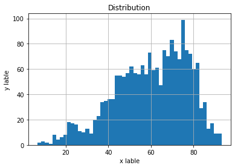

```python
murders['PctBornSameState'].hist(bins=50)
plt.title('Distribution')
plt.xlabel('x lable')
plt.ylabel('y lable')
plt.show()
```

```python
#Check the minimum and maximum value
print(murders['PctBornSameState'].min())
print(murders['PctBornSameState'].max())

#Determine bins based on quantiles
PctBornSameState_ = pd.qcut(murders['PctBornSameState'], q=4)
#Check the value counts of each bin to ensure they are balanced
PctBornSameState_.value_counts()

#Create bin labels
PctBornSameState_labels = ['0-50%', '50-65%', '65-75%', '75-95%']
#Create bins
PctBornSameState_bin = [0, 50, 65, 75, 95]
#Add new category
murders['PctBornSameState_bins'] = pd.cut(murders['PctBornSameState'], bins=PctBornSameState_bin, labels=PctBornSameState_labels)
murders.head()
```

```
6.75
93.14
```

|  | communityname | state | population | householdsize | racepctblack | racePctWhite | racePctAsian | racePctHisp | agePct12t21 | agePct65up | pctUrban | medIncome | pctWFarmSelf | pctWInvInc | pctWPubAsst | pctWRetire | blackPerCap | indianPerCap | AsianPerCap | OtherPerCap | HispPerCap | PctPopUnderPov | PctLess9thGrade | PctBSorMore | PctEmplManu | PctEmplProfServ | PctOccupManu | MalePctDivorce | MalePctNevMarr | … |
| --- | --- | --- | --- | --- | --- | --- | --- | --- | --- | --- | --- | --- | --- | --- | --- | --- | --- | --- | --- | --- | --- | --- | --- | --- | --- | --- | --- | --- | --- | --- |
| 0 | BerkeleyHeightstownship | NJ | 11980 | 3.10 | 1.37 | 91.78 | 6.50 | 1.88 | 12.47 | 11.33 | 100.0 | 75122 | 1.55 | 70.20 | 1.03 | 18.39 | 13600 | 5725 | 27101 | 5115.0 | 22838 | 1.96 | 5.81 | 48.18 | 14.65 | 28.82 | 5.49 | 3.67 | 26.38 | … |
| 1 | Marpletownship | PA | 23123 | 2.82 | 0.80 | 95.57 | 3.44 | 0.85 | 11.01 | 17.18 | 100.0 | 47917 | 1.11 | 64.11 | 2.75 | 22.85 | 18137 | 0 | 20074 | 5250.0 | 12222 | 3.98 | 5.61 | 29.89 | 12.26 | 29.28 | 6.39 | 4.23 | 27.99 | … |
| 2 | Tigardcity | OR | 29344 | 2.43 | 0.74 | 94.33 | 3.43 | 2.35 | 11.36 | 10.28 | 100.0 | 35669 | 1.15 | 55.73 | 2.94 | 14.56 | 16644 | 21606 | 15528 | 5954.0 | 8405 | 4.75 | 2.80 | 30.13 | 15.95 | 21.52 | 8.79 | 10.10 | 25.78 | … |
| 4 | Springfieldcity | MO | 140494 | 2.45 | 2.51 | 95.65 | 0.90 | 0.95 | 18.09 | 13.26 | 100.0 | 21577 | 1.00 | 41.15 | 7.12 | 14.09 | 7382 | 10264 | 10753 | 7192.0 | 8104 | 17.78 | 8.76 | 20.66 | 14.31 | 26.83 | 14.72 | 11.40 | 33.32 | … |
| 5 | Norwoodtown | MA | 28700 | 2.60 | 1.60 | 96.57 | 1.47 | 1.10 | 11.17 | 14.42 | 100.0 | 42805 | 0.39 | 47.70 | 5.41 | 17.23 | 17342 | 21482 | 12639 | 21852.0 | 22594 | 4.01 | 4.49 | 27.01 | 14.02 | 27.17 | 8.50 | 5.97 | 36.05 | … |

```python
murders['PctBornSameState_bins'].value_counts()
```

```
0-50%     535
50-65%    520
65-75%    433
75-95%    431
Name: PctBornSameState_bins, dtype: int64
```

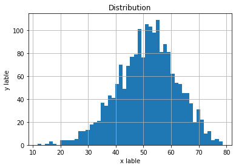

```python
murders['PctSameHouse85'].hist(bins=50)
plt.title('Distribution')
plt.xlabel('x lable')
plt.ylabel('y lable')
plt.show()
```

```python
# apply normalization technique, using a range of [0,1]
murders['PctSameHouse85_norm'] = (murders['PctSameHouse85'] - murders['PctSameHouse85'].min()) / (murders['PctSameHouse85'].max() - murders['PctSameHouse85'].min())

murders.head()
```

|  | communityname | state | population | householdsize | racepctblack | racePctWhite | racePctAsian | racePctHisp | agePct12t21 | agePct65up | pctUrban | medIncome | pctWFarmSelf | pctWInvInc | pctWPubAsst | pctWRetire | blackPerCap | indianPerCap | AsianPerCap | OtherPerCap | HispPerCap | PctPopUnderPov | PctLess9thGrade | PctBSorMore | PctEmplManu | PctEmplProfServ | PctOccupManu | MalePctDivorce | MalePctNevMarr | … |
| --- | --- | --- | --- | --- | --- | --- | --- | --- | --- | --- | --- | --- | --- | --- | --- | --- | --- | --- | --- | --- | --- | --- | --- | --- | --- | --- | --- | --- | --- | --- |
| 0 | BerkeleyHeightstownship | NJ | 11980 | 3.10 | 1.37 | 91.78 | 6.50 | 1.88 | 12.47 | 11.33 | 100.0 | 75122 | 1.55 | 70.20 | 1.03 | 18.39 | 13600 | 5725 | 27101 | 5115.0 | 22838 | 1.96 | 5.81 | 48.18 | 14.65 | 28.82 | 5.49 | 3.67 | 26.38 | … |
| 1 | Marpletownship | PA | 23123 | 2.82 | 0.80 | 95.57 | 3.44 | 0.85 | 11.01 | 17.18 | 100.0 | 47917 | 1.11 | 64.11 | 2.75 | 22.85 | 18137 | 0 | 20074 | 5250.0 | 12222 | 3.98 | 5.61 | 29.89 | 12.26 | 29.28 | 6.39 | 4.23 | 27.99 | … |
| 2 | Tigardcity | OR | 29344 | 2.43 | 0.74 | 94.33 | 3.43 | 2.35 | 11.36 | 10.28 | 100.0 | 35669 | 1.15 | 55.73 | 2.94 | 14.56 | 16644 | 21606 | 15528 | 5954.0 | 8405 | 4.75 | 2.80 | 30.13 | 15.95 | 21.52 | 8.79 | 10.10 | 25.78 | … |
| 4 | Springfieldcity | MO | 140494 | 2.45 | 2.51 | 95.65 | 0.90 | 0.95 | 18.09 | 13.26 | 100.0 | 21577 | 1.00 | 41.15 | 7.12 | 14.09 | 7382 | 10264 | 10753 | 7192.0 | 8104 | 17.78 | 8.76 | 20.66 | 14.31 | 26.83 | 14.72 | 11.40 | 33.32 | … |
| 5 | Norwoodtown | MA | 28700 | 2.60 | 1.60 | 96.57 | 1.47 | 1.10 | 11.17 | 14.42 | 100.0 | 42805 | 0.39 | 47.70 | 5.41 | 17.23 | 17342 | 21482 | 12639 | 21852.0 | 22594 | 4.01 | 4.49 | 27.01 | 14.02 | 27.17 | 8.50 | 5.97 | 36.05 | … |

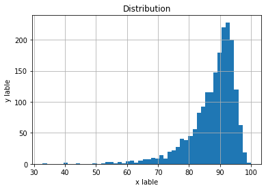

```python
murders['PctSameState85'].hist(bins=50)
plt.title('Distribution')
plt.xlabel('x lable')
plt.ylabel('y lable')
plt.show()
```

```python
#Check the minimum and maximum value
print(murders['PctSameState85'].min())
print(murders['PctSameState85'].max())

#Determine bins based on quantiles
PctSameState85_ = pd.qcut(murders['PctSameState85'], q=4)
#Check the value counts of each bin to ensure they are balanced
PctSameState85_.value_counts()

#Create bin labels
PctSameState85_labels = ['32-85%', '85-90%', '90-93%', '93-100%']
#Create bins
PctSameState85_bin = [32, 85, 90, 93, 100]
#Add new category
murders['PctSameState85_bins'] = pd.cut(murders['PctSameState85'], bins=PctSameState85_bin, labels=PctSameState85_labels)
murders.head()
```

```
32.83
99.9
```

|  | communityname | state | population | householdsize | racepctblack | racePctWhite | racePctAsian | racePctHisp | agePct12t21 | agePct65up | pctUrban | medIncome | pctWFarmSelf | pctWInvInc | pctWPubAsst | pctWRetire | blackPerCap | indianPerCap | AsianPerCap | OtherPerCap | HispPerCap | PctPopUnderPov | PctLess9thGrade | PctBSorMore | PctEmplManu | PctEmplProfServ | PctOccupManu | MalePctDivorce | MalePctNevMarr | … |
| --- | --- | --- | --- | --- | --- | --- | --- | --- | --- | --- | --- | --- | --- | --- | --- | --- | --- | --- | --- | --- | --- | --- | --- | --- | --- | --- | --- | --- | --- | --- |
| 0 | BerkeleyHeightstownship | NJ | 11980 | 3.10 | 1.37 | 91.78 | 6.50 | 1.88 | 12.47 | 11.33 | 100.0 | 75122 | 1.55 | 70.20 | 1.03 | 18.39 | 13600 | 5725 | 27101 | 5115.0 | 22838 | 1.96 | 5.81 | 48.18 | 14.65 | 28.82 | 5.49 | 3.67 | 26.38 | … |
| 1 | Marpletownship | PA | 23123 | 2.82 | 0.80 | 95.57 | 3.44 | 0.85 | 11.01 | 17.18 | 100.0 | 47917 | 1.11 | 64.11 | 2.75 | 22.85 | 18137 | 0 | 20074 | 5250.0 | 12222 | 3.98 | 5.61 | 29.89 | 12.26 | 29.28 | 6.39 | 4.23 | 27.99 | … |
| 2 | Tigardcity | OR | 29344 | 2.43 | 0.74 | 94.33 | 3.43 | 2.35 | 11.36 | 10.28 | 100.0 | 35669 | 1.15 | 55.73 | 2.94 | 14.56 | 16644 | 21606 | 15528 | 5954.0 | 8405 | 4.75 | 2.80 | 30.13 | 15.95 | 21.52 | 8.79 | 10.10 | 25.78 | … |
| 4 | Springfieldcity | MO | 140494 | 2.45 | 2.51 | 95.65 | 0.90 | 0.95 | 18.09 | 13.26 | 100.0 | 21577 | 1.00 | 41.15 | 7.12 | 14.09 | 7382 | 10264 | 10753 | 7192.0 | 8104 | 17.78 | 8.76 | 20.66 | 14.31 | 26.83 | 14.72 | 11.40 | 33.32 | … |
| 5 | Norwoodtown | MA | 28700 | 2.60 | 1.60 | 96.57 | 1.47 | 1.10 | 11.17 | 14.42 | 100.0 | 42805 | 0.39 | 47.70 | 5.41 | 17.23 | 17342 | 21482 | 12639 | 21852.0 | 22594 | 4.01 | 4.49 | 27.01 | 14.02 | 27.17 | 8.50 | 5.97 | 36.05 | … |

```python
murders['PctSameState85_bins'].value_counts()
```

```
32-85%     505
85-90%     500
90-93%     473
93-100%    441
Name: PctSameState85_bins, dtype: int64
```

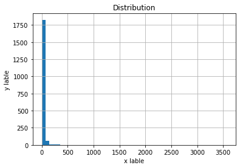

```python
murders['LandArea'].hist(bins=50)
plt.title('Distribution')
plt.xlabel('x lable')
plt.ylabel('y lable')
plt.show()
```

```python
#Check the minimum and maximum value
print(murders['LandArea'].min())
print(murders['LandArea'].max())

#Determine bins based on quantiles
LandArea_ = pd.qcut(murders['LandArea'], q=4)
#Check the value counts of each bin to ensure they are balanced
LandArea_.value_counts()

#Create bin labels
LandArea_labels = ['0-7', '7-14', '14-26', '26-4000']
#Create bins
LandArea_bin = [0, 7, 14, 26, 3570]
#Add new category
murders['LandArea_bins'] = pd.cut(murders['LandArea'], bins=LandArea_bin, labels=LandArea_labels)
murders.head()
```

```
0.9
3569.8
```

|  | communityname | state | population | householdsize | racepctblack | racePctWhite | racePctAsian | racePctHisp | agePct12t21 | agePct65up | pctUrban | medIncome | pctWFarmSelf | pctWInvInc | pctWPubAsst | pctWRetire | blackPerCap | indianPerCap | AsianPerCap | OtherPerCap | HispPerCap | PctPopUnderPov | PctLess9thGrade | PctBSorMore | PctEmplManu | PctEmplProfServ | PctOccupManu | MalePctDivorce | MalePctNevMarr | … |
| --- | --- | --- | --- | --- | --- | --- | --- | --- | --- | --- | --- | --- | --- | --- | --- | --- | --- | --- | --- | --- | --- | --- | --- | --- | --- | --- | --- | --- | --- | --- |
| 0 | BerkeleyHeightstownship | NJ | 11980 | 3.10 | 1.37 | 91.78 | 6.50 | 1.88 | 12.47 | 11.33 | 100.0 | 75122 | 1.55 | 70.20 | 1.03 | 18.39 | 13600 | 5725 | 27101 | 5115.0 | 22838 | 1.96 | 5.81 | 48.18 | 14.65 | 28.82 | 5.49 | 3.67 | 26.38 | … |
| 1 | Marpletownship | PA | 23123 | 2.82 | 0.80 | 95.57 | 3.44 | 0.85 | 11.01 | 17.18 | 100.0 | 47917 | 1.11 | 64.11 | 2.75 | 22.85 | 18137 | 0 | 20074 | 5250.0 | 12222 | 3.98 | 5.61 | 29.89 | 12.26 | 29.28 | 6.39 | 4.23 | 27.99 | … |
| 2 | Tigardcity | OR | 29344 | 2.43 | 0.74 | 94.33 | 3.43 | 2.35 | 11.36 | 10.28 | 100.0 | 35669 | 1.15 | 55.73 | 2.94 | 14.56 | 16644 | 21606 | 15528 | 5954.0 | 8405 | 4.75 | 2.80 | 30.13 | 15.95 | 21.52 | 8.79 | 10.10 | 25.78 | … |
| 4 | Springfieldcity | MO | 140494 | 2.45 | 2.51 | 95.65 | 0.90 | 0.95 | 18.09 | 13.26 | 100.0 | 21577 | 1.00 | 41.15 | 7.12 | 14.09 | 7382 | 10264 | 10753 | 7192.0 | 8104 | 17.78 | 8.76 | 20.66 | 14.31 | 26.83 | 14.72 | 11.40 | 33.32 | … |
| 5 | Norwoodtown | MA | 28700 | 2.60 | 1.60 | 96.57 | 1.47 | 1.10 | 11.17 | 14.42 | 100.0 | 42805 | 0.39 | 47.70 | 5.41 | 17.23 | 17342 | 21482 | 12639 | 21852.0 | 22594 | 4.01 | 4.49 | 27.01 | 14.02 | 27.17 | 8.50 | 5.97 | 36.05 | … |

```python
murders['LandArea_bins'].value_counts()
```

```
7-14       525
0-7        467
26-4000    465
14-26      462
Name: LandArea_bins, dtype: int64
```

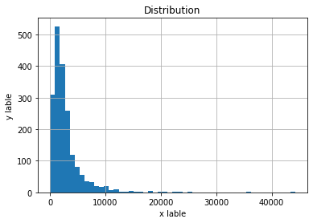

```python
murders['PopDens'].hist(bins=50)
plt.title('Distribution')
plt.xlabel('x lable')
plt.ylabel('y lable')
plt.show()
```

```python
#Check the minimum and maximum value
print(murders['PopDens'].min())
print(murders['PopDens'].max())

#Determine bins based on quantiles
PopDens_ = pd.qcut(murders['PopDens'], q=4)
#Check the value counts of each bin to ensure they are balanced
PopDens_.value_counts()

#Create bin labels
PopDens_labels = ['10-1200', '1200-2000', '2000-3300', '3300-45000']
#Create bins
PopDens_bin = [9, 1200, 2000, 3300, 45000]
#Add new category
murders['PopDens_bins'] = pd.cut(murders['PopDens'], bins=PopDens_bin, labels=PopDens_labels)
murders.head()
```

```
10.0
44229.9
```

|  | communityname | state | population | householdsize | racepctblack | racePctWhite | racePctAsian | racePctHisp | agePct12t21 | agePct65up | pctUrban | medIncome | pctWFarmSelf | pctWInvInc | pctWPubAsst | pctWRetire | blackPerCap | indianPerCap | AsianPerCap | OtherPerCap | HispPerCap | PctPopUnderPov | PctLess9thGrade | PctBSorMore | PctEmplManu | PctEmplProfServ | PctOccupManu | MalePctDivorce | MalePctNevMarr | … |
| --- | --- | --- | --- | --- | --- | --- | --- | --- | --- | --- | --- | --- | --- | --- | --- | --- | --- | --- | --- | --- | --- | --- | --- | --- | --- | --- | --- | --- | --- | --- |
| 0 | BerkeleyHeightstownship | NJ | 11980 | 3.10 | 1.37 | 91.78 | 6.50 | 1.88 | 12.47 | 11.33 | 100.0 | 75122 | 1.55 | 70.20 | 1.03 | 18.39 | 13600 | 5725 | 27101 | 5115.0 | 22838 | 1.96 | 5.81 | 48.18 | 14.65 | 28.82 | 5.49 | 3.67 | 26.38 | … |
| 1 | Marpletownship | PA | 23123 | 2.82 | 0.80 | 95.57 | 3.44 | 0.85 | 11.01 | 17.18 | 100.0 | 47917 | 1.11 | 64.11 | 2.75 | 22.85 | 18137 | 0 | 20074 | 5250.0 | 12222 | 3.98 | 5.61 | 29.89 | 12.26 | 29.28 | 6.39 | 4.23 | 27.99 | … |
| 2 | Tigardcity | OR | 29344 | 2.43 | 0.74 | 94.33 | 3.43 | 2.35 | 11.36 | 10.28 | 100.0 | 35669 | 1.15 | 55.73 | 2.94 | 14.56 | 16644 | 21606 | 15528 | 5954.0 | 8405 | 4.75 | 2.80 | 30.13 | 15.95 | 21.52 | 8.79 | 10.10 | 25.78 | … |
| 4 | Springfieldcity | MO | 140494 | 2.45 | 2.51 | 95.65 | 0.90 | 0.95 | 18.09 | 13.26 | 100.0 | 21577 | 1.00 | 41.15 | 7.12 | 14.09 | 7382 | 10264 | 10753 | 7192.0 | 8104 | 17.78 | 8.76 | 20.66 | 14.31 | 26.83 | 14.72 | 11.40 | 33.32 | … |
| 5 | Norwoodtown | MA | 28700 | 2.60 | 1.60 | 96.57 | 1.47 | 1.10 | 11.17 | 14.42 | 100.0 | 42805 | 0.39 | 47.70 | 5.41 | 17.23 | 17342 | 21482 | 12639 | 21852.0 | 22594 | 4.01 | 4.49 | 27.01 | 14.02 | 27.17 | 8.50 | 5.97 | 36.05 | … |

```python
murders['PopDens_bins'].value_counts()
```

```
10-1200       496
2000-3300     488
3300-45000    478
1200-2000     457
Name: PopDens_bins, dtype: int64
```

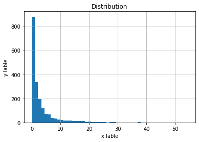

```python
murders['PctUsePubTrans'].hist(bins=50)
plt.title('Distribution')
plt.xlabel('x lable')
plt.ylabel('y lable')
plt.show()
```

```python
#Check the minimum and maximum value
print(murders['PctUsePubTrans'].min())
print(murders['PctUsePubTrans'].max())

#Determine bins based on quantiles
PctUsePubTrans_ = pd.qcut(murders['PctUsePubTrans'], q=4)
#Check the value counts of each bin to ensure they are balanced
PctUsePubTrans_.value_counts()

#Create bin labels
PctUsePubTrans_labels = ['0-0.4%', '0.4-1.2%', '1.2-3.3%', '3.3-55%']
#Create bins
PctUsePubTrans_bin = [-1, 0.4, 1.2, 3.3, 55]
#Add new category
murders['PctUsePubTrans_bins'] = pd.cut(murders['PctUsePubTrans'], bins=PctUsePubTrans_bin, labels=PctUsePubTrans_labels)
murders.head()
```

```
0.0
54.33
```

|  | communityname | state | population | householdsize | racepctblack | racePctWhite | racePctAsian | racePctHisp | agePct12t21 | agePct65up | pctUrban | medIncome | pctWFarmSelf | pctWInvInc | pctWPubAsst | pctWRetire | blackPerCap | indianPerCap | AsianPerCap | OtherPerCap | HispPerCap | PctPopUnderPov | PctLess9thGrade | PctBSorMore | PctEmplManu | PctEmplProfServ | PctOccupManu | MalePctDivorce | MalePctNevMarr | … |
| --- | --- | --- | --- | --- | --- | --- | --- | --- | --- | --- | --- | --- | --- | --- | --- | --- | --- | --- | --- | --- | --- | --- | --- | --- | --- | --- | --- | --- | --- | --- |
| 0 | BerkeleyHeightstownship | NJ | 11980 | 3.10 | 1.37 | 91.78 | 6.50 | 1.88 | 12.47 | 11.33 | 100.0 | 75122 | 1.55 | 70.20 | 1.03 | 18.39 | 13600 | 5725 | 27101 | 5115.0 | 22838 | 1.96 | 5.81 | 48.18 | 14.65 | 28.82 | 5.49 | 3.67 | 26.38 | … |
| 1 | Marpletownship | PA | 23123 | 2.82 | 0.80 | 95.57 | 3.44 | 0.85 | 11.01 | 17.18 | 100.0 | 47917 | 1.11 | 64.11 | 2.75 | 22.85 | 18137 | 0 | 20074 | 5250.0 | 12222 | 3.98 | 5.61 | 29.89 | 12.26 | 29.28 | 6.39 | 4.23 | 27.99 | … |
| 2 | Tigardcity | OR | 29344 | 2.43 | 0.74 | 94.33 | 3.43 | 2.35 | 11.36 | 10.28 | 100.0 | 35669 | 1.15 | 55.73 | 2.94 | 14.56 | 16644 | 21606 | 15528 | 5954.0 | 8405 | 4.75 | 2.80 | 30.13 | 15.95 | 21.52 | 8.79 | 10.10 | 25.78 | … |
| 4 | Springfieldcity | MO | 140494 | 2.45 | 2.51 | 95.65 | 0.90 | 0.95 | 18.09 | 13.26 | 100.0 | 21577 | 1.00 | 41.15 | 7.12 | 14.09 | 7382 | 10264 | 10753 | 7192.0 | 8104 | 17.78 | 8.76 | 20.66 | 14.31 | 26.83 | 14.72 | 11.40 | 33.32 | … |
| 5 | Norwoodtown | MA | 28700 | 2.60 | 1.60 | 96.57 | 1.47 | 1.10 | 11.17 | 14.42 | 100.0 | 42805 | 0.39 | 47.70 | 5.41 | 17.23 | 17342 | 21482 | 12639 | 21852.0 | 22594 | 4.01 | 4.49 | 27.01 | 14.02 | 27.17 | 8.50 | 5.97 | 36.05 | … |

```python
murders['PctUsePubTrans_bins'].value_counts()
```

```
0-0.4%      516
3.3-55%     495
1.2-3.3%    487
0.4-1.2%    421
Name: PctUsePubTrans_bins, dtype: int64
```

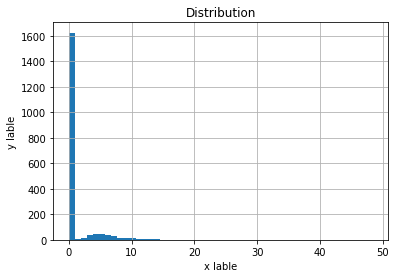

```python
murders['LemasPctOfficDrugUn'].hist(bins=50)
plt.title('Distribution')
plt.xlabel('x lable')
plt.ylabel('y lable')
plt.show()
```

```python
#Check the minimum and maximum value
print(murders['LemasPctOfficDrugUn'].min())
print(murders['LemasPctOfficDrugUn'].max())

#Determine bins based on quantiles
murders['LemasPctOfficDrugUn'].describe()

#Create bin labels
PctUsePubTrans_labels = ['0%', '0.5-50%']
#Create bins
PctUsePubTrans_bin = [-1, 0.44, 60]
#Add new category
murders['PctUsePubTrans_bins'] = pd.cut(murders['PctUsePubTrans'], bins=PctUsePubTrans_bin, labels=PctUsePubTrans_labels)
murders.head()
```

```
0.0
48.44
```

|  | communityname | state | population | householdsize | racepctblack | racePctWhite | racePctAsian | racePctHisp | agePct12t21 | agePct65up | pctUrban | medIncome | pctWFarmSelf | pctWInvInc | pctWPubAsst | pctWRetire | blackPerCap | indianPerCap | AsianPerCap | OtherPerCap | HispPerCap | PctPopUnderPov | PctLess9thGrade | PctBSorMore | PctEmplManu | PctEmplProfServ | PctOccupManu | MalePctDivorce | MalePctNevMarr | … |
| --- | --- | --- | --- | --- | --- | --- | --- | --- | --- | --- | --- | --- | --- | --- | --- | --- | --- | --- | --- | --- | --- | --- | --- | --- | --- | --- | --- | --- | --- | --- |
| 0 | BerkeleyHeightstownship | NJ | 11980 | 3.10 | 1.37 | 91.78 | 6.50 | 1.88 | 12.47 | 11.33 | 100.0 | 75122 | 1.55 | 70.20 | 1.03 | 18.39 | 13600 | 5725 | 27101 | 5115.0 | 22838 | 1.96 | 5.81 | 48.18 | 14.65 | 28.82 | 5.49 | 3.67 | 26.38 | … |
| 1 | Marpletownship | PA | 23123 | 2.82 | 0.80 | 95.57 | 3.44 | 0.85 | 11.01 | 17.18 | 100.0 | 47917 | 1.11 | 64.11 | 2.75 | 22.85 | 18137 | 0 | 20074 | 5250.0 | 12222 | 3.98 | 5.61 | 29.89 | 12.26 | 29.28 | 6.39 | 4.23 | 27.99 | … |
| 2 | Tigardcity | OR | 29344 | 2.43 | 0.74 | 94.33 | 3.43 | 2.35 | 11.36 | 10.28 | 100.0 | 35669 | 1.15 | 55.73 | 2.94 | 14.56 | 16644 | 21606 | 15528 | 5954.0 | 8405 | 4.75 | 2.80 | 30.13 | 15.95 | 21.52 | 8.79 | 10.10 | 25.78 | … |
| 4 | Springfieldcity | MO | 140494 | 2.45 | 2.51 | 95.65 | 0.90 | 0.95 | 18.09 | 13.26 | 100.0 | 21577 | 1.00 | 41.15 | 7.12 | 14.09 | 7382 | 10264 | 10753 | 7192.0 | 8104 | 17.78 | 8.76 | 20.66 | 14.31 | 26.83 | 14.72 | 11.40 | 33.32 | … |
| 5 | Norwoodtown | MA | 28700 | 2.60 | 1.60 | 96.57 | 1.47 | 1.10 | 11.17 | 14.42 | 100.0 | 42805 | 0.39 | 47.70 | 5.41 | 17.23 | 17342 | 21482 | 12639 | 21852.0 | 22594 | 4.01 | 4.49 | 27.01 | 14.02 | 27.17 | 8.50 | 5.97 | 36.05 | … |

```python
murders['PctUsePubTrans_bins'].value_counts()
```

```
0.5-50%    1386
0%          533
Name: PctUsePubTrans_bins, dtype: int64
```

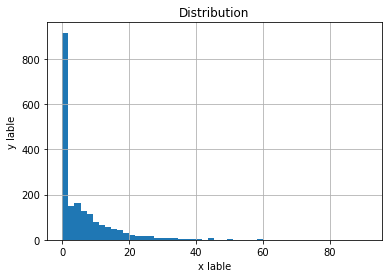

```python
murders['murdPerPop'].hist(bins=50)
plt.title('Distribution')
plt.xlabel('x lable')
plt.ylabel('y lable')
plt.show()
```

```python
murders_backup = murders
```

Prepare the murder dataset for CLASSIFICATION. Here, our target variable will be transformed into a binary categorical variable:

```python
#Check the minimum and maximum value
print(murders['murdPerPop'].min())
print(murders['murdPerPop'].max())

#Determine bins based on quantiles
murdPerPop_ = pd.qcut(murders['murdPerPop'], q=2)
#Check the value counts of each bin to ensure they are balanced
murdPerPop_.value_counts()

#Create bin labels
murdPerPop_labels = ['No', 'Yes']
#Create bins
murdPerPop_bin = [-1, 0, 100]
#Add new category
murders['murdPerPop_class_target'] = pd.cut(murders['murdPerPop'], bins=murdPerPop_bin, labels=murdPerPop_labels)
murders.head()
```

```
0.0
91.09
```

|  | communityname | state | population | householdsize | racepctblack | racePctWhite | racePctAsian | racePctHisp | agePct12t21 | agePct65up | pctUrban | medIncome | pctWFarmSelf | pctWInvInc | pctWPubAsst | pctWRetire | blackPerCap | indianPerCap | AsianPerCap | OtherPerCap | HispPerCap | PctPopUnderPov | PctLess9thGrade | PctBSorMore | PctEmplManu | PctEmplProfServ | PctOccupManu | MalePctDivorce | MalePctNevMarr | … |
| --- | --- | --- | --- | --- | --- | --- | --- | --- | --- | --- | --- | --- | --- | --- | --- | --- | --- | --- | --- | --- | --- | --- | --- | --- | --- | --- | --- | --- | --- | --- |
| 0 | BerkeleyHeightstownship | NJ | 11980 | 3.10 | 1.37 | 91.78 | 6.50 | 1.88 | 12.47 | 11.33 | 100.0 | 75122 | 1.55 | 70.20 | 1.03 | 18.39 | 13600 | 5725 | 27101 | 5115.0 | 22838 | 1.96 | 5.81 | 48.18 | 14.65 | 28.82 | 5.49 | 3.67 | 26.38 | … |
| 1 | Marpletownship | PA | 23123 | 2.82 | 0.80 | 95.57 | 3.44 | 0.85 | 11.01 | 17.18 | 100.0 | 47917 | 1.11 | 64.11 | 2.75 | 22.85 | 18137 | 0 | 20074 | 5250.0 | 12222 | 3.98 | 5.61 | 29.89 | 12.26 | 29.28 | 6.39 | 4.23 | 27.99 | … |
| 2 | Tigardcity | OR | 29344 | 2.43 | 0.74 | 94.33 | 3.43 | 2.35 | 11.36 | 10.28 | 100.0 | 35669 | 1.15 | 55.73 | 2.94 | 14.56 | 16644 | 21606 | 15528 | 5954.0 | 8405 | 4.75 | 2.80 | 30.13 | 15.95 | 21.52 | 8.79 | 10.10 | 25.78 | … |
| 4 | Springfieldcity | MO | 140494 | 2.45 | 2.51 | 95.65 | 0.90 | 0.95 | 18.09 | 13.26 | 100.0 | 21577 | 1.00 | 41.15 | 7.12 | 14.09 | 7382 | 10264 | 10753 | 7192.0 | 8104 | 17.78 | 8.76 | 20.66 | 14.31 | 26.83 | 14.72 | 11.40 | 33.32 | … |
| 5 | Norwoodtown | MA | 28700 | 2.60 | 1.60 | 96.57 | 1.47 | 1.10 | 11.17 | 14.42 | 100.0 | 42805 | 0.39 | 47.70 | 5.41 | 17.23 | 17342 | 21482 | 12639 | 21852.0 | 22594 | 4.01 | 4.49 | 27.01 | 14.02 | 27.17 | 8.50 | 5.97 | 36.05 | … |

```python
murders['murdPerPop_class_target'].value_counts()
```

```
Yes    1043
No      876
Name: murdPerPop_class_target, dtype: int64
```

```python
murders_classification = murders[['state','pop_bins','householdsize_norm', 'racepctblack_bins', 'racePctWhite_bins',
                                  'racePctAsian_bins', 'racePctHisp_bins', 'agePct12t21_norm', 'agePct65up_norm', 'pctUrban_bins',
                                  'medIncome_bins', 'pctWFarmSelf_bins', 'pctWInvInc_norm', 'pctWPubAsst_bins', 'pctWRetire_norm',
                                  'blackPerCap_bins', 'indianPerCap_bins', 'AsianPerCap_bins', 'OtherPerCap_bins', 'HispPerCap_bins',
                                  'PctPopUnderPov_bins', 'PctLess9thGrade_bins', 'PctBSorMore_bins','PctEmplManu_norm','PctEmplProfServ_norm',
                                  'PctOccupManu_norm','MalePctDivorce_norm','MalePctNevMarr_norm','PctFam2Par_bins','PctWorkMomYoungKids_norm',
                                  'PctImmigRecent_bins','PctRecentImmig_bins','PctPersOwnOccup_norm','PctHousLess3BR_norm','MedNumBR_bins',
                                  'PctHousOccup_bins','PctVacantBoarded_bins','PctVacMore6Mos_norm','MedYrHousBuilt_bins','PctWOFullPlumb_bins',
                                  'RentQrange_bins','MedRentPctHousInc_norm','MedOwnCostPctInc_norm','MedOwnCostPctIncNoMtg_bins',
                                  'PctBornSameState_bins','PctSameHouse85_norm','PctSameState85_bins','LandArea_bins','PopDens_bins',
                                  'PctUsePubTrans_bins', 'murdPerPop_class_target']].copy()

murders_classification.head()
murders_classification.info()
```

```
<class 'pandas.core.frame.DataFrame'>
Int64Index: 1919 entries, 0 to 2214
Data columns (total 51 columns):
 #   Column                      Non-Null Count  Dtype
---  ------                      --------------  -----
 0   state                       1919 non-null   object
 1   pop_bins                    1919 non-null   category
 2   householdsize_norm          1919 non-null   float64
 3   racepctblack_bins           1919 non-null   category
 4   racePctWhite_bins           1919 non-null   category
 5   racePctAsian_bins           1919 non-null   category
 6   racePctHisp_bins            1919 non-null   category
 7   agePct12t21_norm            1919 non-null   float64
 8   agePct65up_norm             1919 non-null   float64
 9   pctUrban_bins               1919 non-null   category
```

[output cut: 43 more lines]

```python
murders_class_backup = murders_classification
murders_class_backup.info()
```

```python
murders_classification['state'] = murders_classification['state'].astype('category')
```

```python
murders_class_backup = murders_classification
```

Prepare the murder dataset for REGRESSION. Here, the target variable will be normalized numerically.

***min/max scalar function

```python
# apply normalization technique, using a range of [0,1]
murders['murdPerPop_reg_target'] = (murders['murdPerPop'] - murders['murdPerPop'].min()) / (murders['murdPerPop'].max() - murders['murdPerPop'].min())

murders.head()
```

```python
murders_regression = murders[['state','pop_bins','householdsize_norm', 'racepctblack_bins', 'racePctWhite_bins',
                              'racePctAsian_bins', 'racePctHisp_bins', 'agePct12t21_norm', 'agePct65up_norm', 'pctUrban_bins',
                              'medIncome_bins', 'pctWFarmSelf_bins', 'pctWInvInc_norm', 'pctWPubAsst_bins', 'pctWRetire_norm',
                              'blackPerCap_bins', 'indianPerCap_bins', 'AsianPerCap_bins', 'OtherPerCap_bins', 'HispPerCap_bins',
                              'PctPopUnderPov_bins', 'PctLess9thGrade_bins', 'PctBSorMore_bins','PctEmplManu_norm','PctEmplProfServ_norm',
                              'PctOccupManu_norm','MalePctDivorce_norm','MalePctNevMarr_norm','PctFam2Par_bins','PctWorkMomYoungKids_norm',
                              'PctImmigRecent_bins','PctRecentImmig_bins','PctPersOwnOccup_norm','PctHousLess3BR_norm','MedNumBR_bins',
                              'PctHousOccup_bins','PctVacantBoarded_bins','PctVacMore6Mos_norm','MedYrHousBuilt_bins','PctWOFullPlumb_bins',
                              'RentQrange_bins','MedRentPctHousInc_norm','MedOwnCostPctInc_norm','MedOwnCostPctIncNoMtg_bins',
                              'PctBornSameState_bins','PctSameHouse85_norm','PctSameState85_bins','LandArea_bins','PopDens_bins',
                              'PctUsePubTrans_bins', 'murdPerPop_reg_target']].copy()

murders_regression.head()
```

|  | state | pop_bins | householdsize_norm | racepctblack_bins | racePctWhite_bins | racePctAsian_bins | racePctHisp_bins | agePct12t21_norm | agePct65up_norm | pctUrban_bins | medIncome_bins | pctWFarmSelf_bins | pctWInvInc_norm | pctWPubAsst_bins | pctWRetire_norm | blackPerCap_bins | indianPerCap_bins | AsianPerCap_bins | OtherPerCap_bins | HispPerCap_bins | PctPopUnderPov_bins | PctLess9thGrade_bins | PctBSorMore_bins | PctEmplManu_norm | PctEmplProfServ_norm | PctOccupManu_norm | MalePctDivorce_norm | MalePctNevMarr_norm | PctFam2Par_bins | … |
| --- | --- | --- | --- | --- | --- | --- | --- | --- | --- | --- | --- | --- | --- | --- | --- | --- | --- | --- | --- | --- | --- | --- | --- | --- | --- | --- | --- | --- | --- | --- |
| 0 | NJ | 10000-13500 | 0.407609 | 0.9-2.8% | 90-96% | 2.7-57.5% | 0.9-2.2% | 0.158370 | 0.189200 | 100% | 42,000-$125,000 | 1.0-7.0% | 0.764559 | 0-3% | 0.355054 | 10000-15000 | 0-6500 | 17500-106500 | 0-5500 | 13500-55000 | 0-5% | 5-8% | 30-80 | 0.262609 | 0.372916 | 0.096037 | 0.090802 | 0.222845 | 82-95% | … |
| 1 | PA | 19000-29000 | 0.331522 | 0-0.8% | 90-96% | 2.7-57.5% | 0.1-0.9% | 0.129065 | 0.303659 | 100% | 42,000-$125,000 | 1.0-7.0% | 0.688453 | 0-3% | 0.461118 | 15000-250000 | 0-6500 | 17500-106500 | 0-5500 | 1000-13500 | 0-5% | 5-8% | 19-30 | 0.212797 | 0.381438 | 0.117016 | 0.123821 | 0.247899 | 82-95% | … |
| 2 | OR | 29000-51500 | 0.225543 | 0-0.8% | 90-96% | 2.7-57.5% | 0.9-2.2% | 0.136090 | 0.168656 | 100% | $32,000-$42,000 | 1.0-7.0% | 0.583729 | 0-3% | 0.263971 | 15000-250000 | 15000-500000 | 12500-17500 | 5500-8000 | 7500-1000 | 0-5% | 0-5% | 30-80 | 0.289704 | 0.237681 | 0.172960 | 0.469929 | 0.213508 | 75-82% | … |
| 4 | MO | 515000-7500000 | 0.230978 | 0.9-2.8% | 90-96% | 0.6-1.2% | 0.1-0.9% | 0.271176 | 0.226961 | 100% | $8,000-$24,000 | 0.7-1.0% | 0.401525 | 5-8% | 0.252794 | 6500-10000 | 10000-15000 | 8500-12500 | 5500-8000 | 7500-1000 | 17-60% | 8-12% | 19-30 | 0.255523 | 0.336050 | 0.311189 | 0.546580 | 0.330843 | 67-70% | … |
| 5 | MA | 19000-29000 | 0.271739 | 0.9-2.8% | 96-100% | 1.2-2.6% | 0.9-2.2% | 0.132276 | 0.249658 | 100% | 42,000-$125,000 | 0-0.5% | 0.483379 | 5-8% | 0.327467 | 15000-250000 | 15000-500000 | 12500-17500 | 11500-137000 | 13500-55000 | 0-5% | 0-5% | 19-30 | 0.249479 | 0.342349 | 0.166200 | 0.226415 | 0.373327 | 75-82% | … |

```python
murders_reg_backup = murders_regression
```

```python
murders_regression['state'] = murders_regression['state'].astype('category')
```

ROBBERY CATEGORY:

```python
robberies_data = crimedata_new.drop(['rapes', 'rapesPerPop', 'murders', 'murdPerPop', 'assaults', 'assaultPerPop', 'burglaries', 'burglPerPop', 'larcenies', 'larcPerPop', 'autoTheft', 'autoTheftPerPop', 'arsons', 'arsonsPerPop', 'ViolentCrimesPerPop', 'nonViolPerPop'], axis=1)
robberies_data.head()
```

|  | communityname | state | population | householdsize | racepctblack | racePctWhite | racePctAsian | racePctHisp | agePct12t21 | agePct12t29 | agePct16t24 | agePct65up | numbUrban | pctUrban | medIncome | pctWWage | pctWFarmSelf | pctWInvInc | pctWSocSec | pctWPubAsst | pctWRetire | medFamInc | perCapInc | whitePerCap | blackPerCap | indianPerCap | AsianPerCap | OtherPerCap | HispPerCap | … |
| --- | --- | --- | --- | --- | --- | --- | --- | --- | --- | --- | --- | --- | --- | --- | --- | --- | --- | --- | --- | --- | --- | --- | --- | --- | --- | --- | --- | --- | --- | --- |
| 0 | BerkeleyHeightstownship | NJ | 11980 | 3.10 | 1.37 | 91.78 | 6.50 | 1.88 | 12.47 | 21.44 | 10.93 | 11.33 | 11980 | 100.0 | 75122 | 89.24 | 1.55 | 70.20 | 23.62 | 1.03 | 18.39 | 79584 | 29711 | 30233 | 13600 | 5725 | 27101 | 5115.0 | 22838 | … |
| 1 | Marpletownship | PA | 23123 | 2.82 | 0.80 | 95.57 | 3.44 | 0.85 | 11.01 | 21.30 | 10.48 | 17.18 | 23123 | 100.0 | 47917 | 78.99 | 1.11 | 64.11 | 35.50 | 2.75 | 22.85 | 55323 | 20148 | 20191 | 18137 | 0 | 20074 | 5250.0 | 12222 | … |
| 2 | Tigardcity | OR | 29344 | 2.43 | 0.74 | 94.33 | 3.43 | 2.35 | 11.36 | 25.88 | 11.01 | 10.28 | 29344 | 100.0 | 35669 | 82.00 | 1.15 | 55.73 | 22.25 | 2.94 | 14.56 | 42112 | 16946 | 17103 | 16644 | 21606 | 15528 | 5954.0 | 8405 | … |
| 4 | Springfieldcity | MO | 140494 | 2.45 | 2.51 | 95.65 | 0.90 | 0.95 | 18.09 | 32.89 | 20.04 | 13.26 | 140494 | 100.0 | 21577 | 75.78 | 1.00 | 41.15 | 29.31 | 7.12 | 14.09 | 27705 | 11878 | 12029 | 7382 | 10264 | 10753 | 7192.0 | 8104 | … |
| 5 | Norwoodtown | MA | 28700 | 2.60 | 1.60 | 96.57 | 1.47 | 1.10 | 11.17 | 27.41 | 12.76 | 14.42 | 28700 | 100.0 | 42805 | 79.47 | 0.39 | 47.70 | 30.23 | 5.41 | 17.23 | 50394 | 18193 | 18276 | 17342 | 21482 | 12639 | 21852.0 | 22594 | … |

```python
robberies_data.info()
```

```
<class 'pandas.core.frame.DataFrame'>
Int64Index: 1919 entries, 0 to 2214
Columns: 106 entries, communityname to robbbPerPop
dtypes: float64(77), int64(27), object(2)
memory usage: 1.6+ MB
```

```python
#Examine the correlations of each columns and 'robbbPerPop' as our target variable
robbbPerPop_corr = robberies_data[robberies_data.columns[1:]].corr()['robbbPerPop'][:]

#Sort the values so we can see the positive and negative correlations clearly
robbbPerPop_corr.sort_values()
```

```python
#Examine the correlations of each columns and 'robberies' as our target variable
robberies_corr = robberies_data[robberies_data.columns[1:]].corr()['robberies'][:]

#Sort the values so we can see the positive and negative correlations clearly
robberies_corr.sort_values()
```

```python
#Create a correlation matrix for the dataframe category
robb_corr = robberies_data.corr(numeric_only=True).abs()

#Select the upper triangle of the matrix, excluding the diagnonal elements
robb_tri = robb_corr.where(np.triu(np.ones(robb_corr.shape),k=1).astype(bool))

#drop the columns with a correlation greater than 0.8 and make a list of those columns
robb_drop = [column for column in robb_tri.columns if any(robb_tri[column] > 0.8)]

#drop the columns in the previous list from the dataframe
robberies = robberies_data.drop(robberies_data[robb_drop], axis=1)

robberies.head()
```

|  | communityname | state | population | householdsize | racepctblack | racePctWhite | racePctAsian | racePctHisp | agePct12t21 | agePct65up | pctUrban | medIncome | pctWFarmSelf | pctWInvInc | pctWPubAsst | pctWRetire | blackPerCap | indianPerCap | AsianPerCap | OtherPerCap | HispPerCap | PctPopUnderPov | PctLess9thGrade | PctBSorMore | PctEmplManu | PctEmplProfServ | PctOccupManu | MalePctDivorce | MalePctNevMarr | … |
| --- | --- | --- | --- | --- | --- | --- | --- | --- | --- | --- | --- | --- | --- | --- | --- | --- | --- | --- | --- | --- | --- | --- | --- | --- | --- | --- | --- | --- | --- | --- |
| 0 | BerkeleyHeightstownship | NJ | 11980 | 3.10 | 1.37 | 91.78 | 6.50 | 1.88 | 12.47 | 11.33 | 100.0 | 75122 | 1.55 | 70.20 | 1.03 | 18.39 | 13600 | 5725 | 27101 | 5115.0 | 22838 | 1.96 | 5.81 | 48.18 | 14.65 | 28.82 | 5.49 | 3.67 | 26.38 | … |
| 1 | Marpletownship | PA | 23123 | 2.82 | 0.80 | 95.57 | 3.44 | 0.85 | 11.01 | 17.18 | 100.0 | 47917 | 1.11 | 64.11 | 2.75 | 22.85 | 18137 | 0 | 20074 | 5250.0 | 12222 | 3.98 | 5.61 | 29.89 | 12.26 | 29.28 | 6.39 | 4.23 | 27.99 | … |
| 2 | Tigardcity | OR | 29344 | 2.43 | 0.74 | 94.33 | 3.43 | 2.35 | 11.36 | 10.28 | 100.0 | 35669 | 1.15 | 55.73 | 2.94 | 14.56 | 16644 | 21606 | 15528 | 5954.0 | 8405 | 4.75 | 2.80 | 30.13 | 15.95 | 21.52 | 8.79 | 10.10 | 25.78 | … |
| 4 | Springfieldcity | MO | 140494 | 2.45 | 2.51 | 95.65 | 0.90 | 0.95 | 18.09 | 13.26 | 100.0 | 21577 | 1.00 | 41.15 | 7.12 | 14.09 | 7382 | 10264 | 10753 | 7192.0 | 8104 | 17.78 | 8.76 | 20.66 | 14.31 | 26.83 | 14.72 | 11.40 | 33.32 | … |
| 5 | Norwoodtown | MA | 28700 | 2.60 | 1.60 | 96.57 | 1.47 | 1.10 | 11.17 | 14.42 | 100.0 | 42805 | 0.39 | 47.70 | 5.41 | 17.23 | 17342 | 21482 | 12639 | 21852.0 | 22594 | 4.01 | 4.49 | 27.01 | 14.02 | 27.17 | 8.50 | 5.97 | 36.05 | … |

Here, I want to make sure both murders and robberies datasets contain the same columns, to avoid repeating the same normalization steps.

```python
print(murders_copy.columns.difference(robberies.columns))
print(robberies.columns.difference(murders_copy.columns))
```

```
Index(['murdPerPop'], dtype='object')
Index(['robbbPerPop'], dtype='object')
```

Both dataframes have the exact columns, other than their target variables. Because of this, I will only normalize the robbbPerPop target variable, and create new datasets in preparation for our regression and classification models using previously normalized columns from the murders dataset.

```python
murders.head()
```

|  | communityname | state | population | householdsize | racepctblack | racePctWhite | racePctAsian | racePctHisp | agePct12t21 | agePct65up | pctUrban | medIncome | pctWFarmSelf | pctWInvInc | pctWPubAsst | pctWRetire | blackPerCap | indianPerCap | AsianPerCap | OtherPerCap | HispPerCap | PctPopUnderPov | PctLess9thGrade | PctBSorMore | PctEmplManu | PctEmplProfServ | PctOccupManu | MalePctDivorce | MalePctNevMarr | … |
| --- | --- | --- | --- | --- | --- | --- | --- | --- | --- | --- | --- | --- | --- | --- | --- | --- | --- | --- | --- | --- | --- | --- | --- | --- | --- | --- | --- | --- | --- | --- |
| 0 | BerkeleyHeightstownship | NJ | 11980 | 3.10 | 1.37 | 91.78 | 6.50 | 1.88 | 12.47 | 11.33 | 100.0 | 75122 | 1.55 | 70.20 | 1.03 | 18.39 | 13600 | 5725 | 27101 | 5115.0 | 22838 | 1.96 | 5.81 | 48.18 | 14.65 | 28.82 | 5.49 | 3.67 | 26.38 | … |
| 1 | Marpletownship | PA | 23123 | 2.82 | 0.80 | 95.57 | 3.44 | 0.85 | 11.01 | 17.18 | 100.0 | 47917 | 1.11 | 64.11 | 2.75 | 22.85 | 18137 | 0 | 20074 | 5250.0 | 12222 | 3.98 | 5.61 | 29.89 | 12.26 | 29.28 | 6.39 | 4.23 | 27.99 | … |
| 2 | Tigardcity | OR | 29344 | 2.43 | 0.74 | 94.33 | 3.43 | 2.35 | 11.36 | 10.28 | 100.0 | 35669 | 1.15 | 55.73 | 2.94 | 14.56 | 16644 | 21606 | 15528 | 5954.0 | 8405 | 4.75 | 2.80 | 30.13 | 15.95 | 21.52 | 8.79 | 10.10 | 25.78 | … |
| 4 | Springfieldcity | MO | 140494 | 2.45 | 2.51 | 95.65 | 0.90 | 0.95 | 18.09 | 13.26 | 100.0 | 21577 | 1.00 | 41.15 | 7.12 | 14.09 | 7382 | 10264 | 10753 | 7192.0 | 8104 | 17.78 | 8.76 | 20.66 | 14.31 | 26.83 | 14.72 | 11.40 | 33.32 | … |
| 5 | Norwoodtown | MA | 28700 | 2.60 | 1.60 | 96.57 | 1.47 | 1.10 | 11.17 | 14.42 | 100.0 | 42805 | 0.39 | 47.70 | 5.41 | 17.23 | 17342 | 21482 | 12639 | 21852.0 | 22594 | 4.01 | 4.49 | 27.01 | 14.02 | 27.17 | 8.50 | 5.97 | 36.05 | … |

```python
#Create our normalized robberies dataframes

#REGRESSION DATASET
robberies_regression = murders[['state','pop_bins','householdsize_norm', 'racepctblack_bins', 'racePctWhite_bins',
                                'racePctAsian_bins', 'racePctHisp_bins', 'agePct12t21_norm', 'agePct65up_norm', 'pctUrban_bins', 'medIncome_bins',
                                  'pctWFarmSelf_bins', 'pctWInvInc_norm', 'pctWPubAsst_bins', 'pctWRetire_norm', 'blackPerCap_bins',
                                  'indianPerCap_bins', 'AsianPerCap_bins', 'OtherPerCap_bins', 'HispPerCap_bins', 'PctPopUnderPov_bins',
                                  'PctLess9thGrade_bins', 'PctBSorMore_bins','PctEmplManu_norm','PctEmplProfServ_norm','PctOccupManu_norm',
                                  'MalePctDivorce_norm','MalePctNevMarr_norm','PctFam2Par_bins','PctWorkMomYoungKids_norm','PctImmigRecent_bins',
                                  'PctRecentImmig_bins','PctPersOwnOccup_norm','PctHousLess3BR_norm','MedNumBR_bins','PctHousOccup_bins',
                                  'PctVacantBoarded_bins','PctVacMore6Mos_norm','MedYrHousBuilt_bins','PctWOFullPlumb_bins','RentQrange_bins',
                                  'MedRentPctHousInc_norm','MedOwnCostPctInc_norm','MedOwnCostPctIncNoMtg_bins','PctBornSameState_bins',
                                  'PctSameHouse85_norm','PctSameState85_bins','LandArea_bins','PopDens_bins','PctUsePubTrans_bins']].copy()

robberies_regression.info()
```